# Module 194

#### Contrast SVE:

Signed variance explained (SVE) provides an indication of how similar a set of fold changes are to a gene module’s weight vector. An SVE value of 0.3, for example, indicates that 30% of the variance explained by the entire module set is accounted for by the module in question. Shown here are the SVE values for this module across a compendium of fold changes (contrasts). Extreme SVE values (e.g., > 0.05) indicate that those contrasts specifically induce (orange dots) or specifically repress (blue dots) this module. Examining the experimental conditions being compared in such contrasts (see tables below the figure) may provide insight into the gene module’s function.

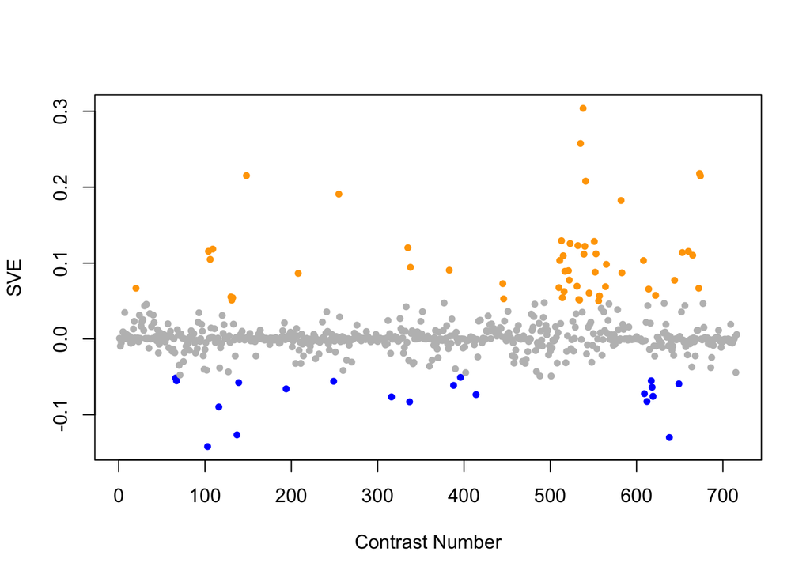

Positive SVE Contrasts:

|  | Contrast.Num | SVE | GEO.GSE | Cond.1 | Cond.2 | Mutation |
| --- | --- | --- | --- | --- | --- | --- |
| GSE2180.s4t10.vs.s3t10 | 538 | 0.30 | GSE2180 | pp186-1 | p186-2 | pal-1(RNAi) |
| GSE2180.s4t10.vs.s1t10 | 535 | 0.26 | GSE2180 | pp186-1 | 186-1 | pie-1(zu154);pal-1(RNAi) |
| GSE14640B.s1t1.vs.s0t1 | 673 | 0.22 | GSE14640 | XX_DPY27-N_042807_A | XX_WT-N_080307_A |  |
| GSE48347.s2t1.vs.s0t1 | 148 | 0.22 | GSE48347 | sdc2_embryo_rep1 | WT_embryo_rep1 | sdc-2 |
| GSE14640C.s1t1.vs.s0t1 | 674 | 0.21 | GSE14640 | XX_SDC2Y93R-P-022208_A | XX_WT-P_081407_A |  |
| GSE2180.s4t2.vs.s1t2 | 541 | 0.21 | GSE2180 | pp23-1 | 23-1 | pie-1(zu154);pal-1(RNAi) |
| GSE41486.s2t1.vs.s1t1 | 255 | 0.19 | GSE41486 | C. elegans grown without a-SWCNT treatment for 48 hr at 22°C. | C. elegans exposed to 500 μg/mL of a-SWCNT for 48 hr at 22°C. |  |
| GSE2180.s2t2.vs.s2t1 | 582 | 0.18 | GSE2180 | ms23-1 | ms0-1 |  |
| GSE2180.s4t1.vs.s2t1 | 513 | 0.13 | GSE2180 | pp0-1 | ms0-1 |  |
| GSE2180.s2t4.vs.s1t4 | 551 | 0.13 | GSE2180 | ms53-4 | 53-1 | mex-3(zu155);skn-1(RNAi) |
| GSE2180.s4t8.vs.s1t8 | 523 | 0.13 | GSE2180 | pp122-1 | 122-1 | pie-1(zu154);pal-1(RNAi) |
| GSE2180.s4t9.vs.s3t9 | 532 | 0.12 | GSE2180 | pp143-1 | p143-2 | pal-1(RNAi) |
| GSE2180.s3t2.vs.s1t2 | 540 | 0.12 | GSE2180 | p23-2 | 23-1 | pie-1(zu154) |
| GSE38997.s3t2.vs.s2t2 | 335 | 0.12 | GSE38997 | experiment 4 UVC- and EtBr-exposed samples at 24 h 4eu24 | experiment 4 EtBr-exposed samples at 24 h 4e24 |  |
| GSE54513.s4t1.vs.s2t1 | 109 | 0.12 | GSE54513 | spe-9 OMA-1 IP rep1 | fog-1 OMA-1 IP rep1 |  |
| GSE57664.s1t1.vs.s0t1 | 104 | 0.12 | GSE57664 | TYR treated rep1 | control rep1 |  |
| GSE15527.s2t1.vs.s1t1 | 660 | 0.12 | GSE15527 | sma-6 L4 worm, biological rep1 | dbl-1 L4 worm, biological rep1 | dbl-1 |
| GSE16405.s4t1.vs.s2t1 | 653 | 0.11 | GSE16405 | xpa-1_1 | nth-1_1 | nth-1 vs. xpa-1 |
| GSE2180.s4t4.vs.s1t4 | 553 | 0.11 | GSE2180 | pp53-1 | 53-1 | pie-1(zu154);pal-1(RNAi) |
| GSE2180.s2t2.vs.s1t2 | 539 | 0.11 | GSE2180 | ms23-1 | 23-1 | mex-3(zu155);skn-1(RNAi) |
| GSE15159.s1t2.vs.s1t1 | 665 | 0.11 | GSE15159 | glp-1_UV_2007_rep1 | glp-1_control_2007_rep1 |  |
| GSE2180.s2t7.vs.s1t7 | 515 | 0.11 | GSE2180 | ms101-2 | 101G | mex-3(zu155);skn-1(RNAi) |
| GSE54513.s3t1.vs.s1t1 | 106 | 0.10 | GSE54513 | spe-9 input rep1 | fog-1 input rep1 |  |
| GSE2180.s4t1.vs.s1t1 | 511 | 0.10 | GSE2180 | pp0-1 | 00B | pie-1(zu154);pal-1(RNAi) |
| GSE21747.s1t1.vs.s0t1 | 608 | 0.10 | GSE21747 | albendazole exposure, biological rep 1 | no albendazole exposure, biological rep 1 |  |
| GSE2180.s4t6.vs.s1t6 | 565 | 0.10 | GSE2180 | pp83-1 | 83-1 | pie-1(zu154);pal-1(RNAi) |
| GSE38997.s2t1.vs.s1t1 | 338 | 0.09 | GSE38997 | experiment 4 EtBr-exposed samples at 3 h 4e3 | experiment 4 control samples at 3 h 4c3 |  |
| GSE34113.s1t1.vs.s0t1 | 383 | 0.09 | GSE34113 | tdp-1(ok803) | wild-type 1 | tdp-1 |
| GSE2180.s2t8.vs.s1t8 | 521 | 0.09 | GSE2180 | ms122-1 | 122-1 | mex-3(zu155);skn-1(RNAi) |
| GSE2180.s4t7.vs.s1t7 | 517 | 0.09 | GSE2180 | pp101-1 | 101G | pie-1(zu154);pal-1(RNAi) |
| GSE2180.s3t4.vs.s1t4 | 552 | 0.09 | GSE2180 | p53-2 | 53-1 | pie-1(zu154) |
| GSE2180.s2t3.vs.s2t1 | 583 | 0.09 | GSE2180 | ms41-1 | ms0-1 |  |
| GSE42703.s2t2.vs.s2t1 | 208 | 0.09 | GSE42703 | WT incubated with H2O, biological rep1 | WT incubated with 1mM copper sulfate, biological rep1 |  |
| GSE2180.s3t8.vs.s1t8 | 522 | 0.08 | GSE2180 | p122-2 | 122-1 | pie-1(zu154) |
| GSE16915.s1t1.vs.s3t1 | 644 | 0.08 | GSE16915 | control sample | bio-electrosprayed sample |  |
| GSE27677B.s0t9.vs.s0t7 | 445 | 0.07 | GSE27677 | N2, Fed 48 h, rep 1 | N2, Fed 24 h, rep 1 |  |
| GSE2180.s4t9.vs.s2t9 | 531 | 0.07 | GSE2180 | pp143-1 | ms143-2 |  |
| GSE2180.s3t6.vs.s1t6 | 564 | 0.07 | GSE2180 | p83-2 | 83-1 | pie-1(zu154) |
| GSE2180.s3t1.vs.s1t1 | 510 | 0.07 | GSE2180 | p0-3 | 00B | pie-1(zu154) |
| GSE9665.s9t1.vs.s0t1 | 20 | 0.07 | GSE9665 | mex-3 scrt-1 143 A | mex-3 143 A | scrt-1 |
| GSE14640A.s1t1.vs.s0t1 | 672 | 0.07 | GSE14640 | XO_TY2222-E_080307_A | XX_WT-E_080307_A |  |
| GSE21591.s2t1.vs.s4t1 | 614 | 0.07 | GSE21591 | Input_1 | aMYC_1 |  |
| GSE2180.s3t7.vs.s1t7 | 516 | 0.06 | GSE2180 | p101-2 | 101G | pie-1(zu154) |
| GSE2180.s2t3.vs.s1t3 | 545 | 0.06 | GSE2180 | ms41-1 | 41D | mex-3(zu155);skn-1(RNAi) |
| GSE21162.s1t1.vs.s0t1 | 622 | 0.06 | GSE21162 | PVD and OLL neurons, biological rep1 | L3/L4 stage whole animal reference, rep1 |  |
| GSE2180.s2t5.vs.s1t5 | 557 | 0.06 | GSE2180 | ms66-3 | 66-4 | mex-3(zu155);skn-1(RNAi) |
| GSE52064.s4t1.vs.s3t1 | 130 | 0.06 | GSE52064 | lin-54;mes-4_1 | lin-54_1 | mes-4 |
| GSE52064.s1t1.vs.s3t1 | 132 | 0.05 | GSE52064 | wildtype_1 | lin-54_1 | lin-54 |
| GSE2180.s4t1.vs.s3t1 | 514 | 0.05 | GSE2180 | pp0-1 | p0-3 | pal-1(RNAi) |
| GSE27401.s2t1.vs.s3t1 | 446 | 0.05 | GSE27401 | Heat Killed C. albicans #1 | C. albicans alive #1 |  |
| GSE2180.s2t10.vs.s1t10 | 533 | 0.05 | GSE2180 | ms186-5 | 186-1 | mex-3(zu155);skn-1(RNAi) |
| GSE2180.s3t10.vs.s1t10 | 534 | 0.05 | GSE2180 | p186-2 | 186-1 | pie-1(zu154) |
| GSE52064.s2t1.vs.s3t1 | 131 | 0.05 | GSE52064 | mes-4_1 | lin-54_1 | mes-4 vs. lin-54 |
| GSE2180.s4t4.vs.s3t4 | 556 | 0.05 | GSE2180 | pp53-1 | p53-2 |  |

Negative SVE Contrasts:

|  | Contrast.Num | SVE | GEO.GSE | Cond.1 | Cond.2 | Mutation |
| --- | --- | --- | --- | --- | --- | --- |
| GSE5793.s3t2.vs.s3t1 | 103 | -0.14 | GSE5793 | Celegans_PA14_8hours_RepA | Celegans_PA14_4hours_RepA |  |
| GSE18132.s2t1.vs.s0t1 | 638 | -0.13 | GSE18132 | Oga starved L1, biological replicate 1 | WT Starved L1, biological rep1 | oga-1 |
| GSE51691.s3t1.vs.s1t1 | 137 | -0.13 | GSE51691 | day8 hermaphrodite utx-1 RNAi -males rep 1 | day8 hermaphrodite -males rep 1 | utx-1(RNAi) |
| GSE54024.s4t1.vs.s6t1 | 116 | -0.09 | GSE54024 | isp-1(qm150) young adults, biological rep 1 | isp-1(qm150) ced-4(n1162) double mutant young adults, biological rep 1 | ced-4 |
| GSE38997.s4t2.vs.s3t2 | 337 | -0.08 | GSE38997 | experiment 4 UVC-exposed samples at 24 h 4u24 | experiment 4 UVC- and EtBr-exposed samples at 24 h 4eu24 |  |
| GSE21591.s1t1.vs.s5t1 | 612 | -0.08 | GSE21591 | N2_aFLAG_1 | aFLAG_1 |  |
| GSE39252.s1t1.vs.s0t1 | 316 | -0.08 | GSE39252 | xpa-1_rep1 | N2_rep1 | xpa-1 |
| GSE21467.s1t1.vs.s0t1 | 619 | -0.08 | GSE21467 | ung-1, biological rep1 | wild type N2, biological rep1 | ung-1 |
| GSE29951.s1t1.vs.s0t1 | 414 | -0.07 | GSE29951 | C.elegans MT KO mtl-1,mtl-2(zs1), raised in the absence of Cd, rep1 | C.elegans wild type raised in the absence of Cd, rep1 | mtl-1;mtl-2 |
| GSE21591.s4t1.vs.s5t1 | 609 | -0.07 | GSE21591 | aMYC_1 | aFLAG_1 |  |
| GSE44318.s1t1.vs.s0t1 | 194 | -0.07 | GSE44318 | 13L peptide [SL12] | NGM [SL1] |  |
| GSE21591.s1t1.vs.s2t1 | 618 | -0.06 | GSE21591 | N2_aFLAG_1 | Input_1 |  |
| GSE32949.s1t1.vs.s0t1 | 388 | -0.06 | GSE32949 | C. elegans exposed to space condition, technical rep1 | C. elegans ground control, technical rep1 |  |
| GSE16405.s2t1.vs.s1t1 | 649 | -0.06 | GSE16405 | nth-1_1 | N2_1 | nth-1 |
| GSE51691.s3t1.vs.s2t1 | 139 | -0.06 | GSE51691 | day8 hermaphrodite utx-1 RNAi -males rep 1 | day8 hermaphrodite +males rep 1 |  |
| GSE42192.s2t2.vs.s0t2 | 249 | -0.06 | GSE42192 | C.elegans fed with CNCM I-4317 10 days rep1 | C.elegans fed with E.coli OP50 10 days rep1 |  |
| GSE8659.s3t1.vs.s2t1 | 67 | -0.06 | GSE8659 | strain NL 2099 replicate 2 | strain GR1373 replicate 1 |  |
| GSE21591.s1t1.vs.s3t1 | 617 | -0.06 | GSE21591 | N2_aFLAG_1 | GGF_aFLAG_1 |  |
| GSE8659.s3t1.vs.s1t1 | 66 | -0.05 | GSE8659 | strain NL 2099 replicate 2 | N2 replicate 1 | rrf-3 |
| GSE32031.s1t1.vs.s0t1 | 396 | -0.05 | GSE32031 | Exerimental (nhr-23 RNAi), biological rep1 | Control, biological rep1 | nhr-23 |

$~$

#### Contrast SVE, Up-Regulated Genes Only:

Calculating SVE for up-regulated and down-regulated genes separately may be more informative in many cases than projecting the up- and down- gene sets together. This is due to the fact that the weight distribution of many modules is highly skewed, indicating that only one of the hemi-modules may be biologically meaningful (i.e., a set of genes are strongly correlated by only a few genes (or none) are strongly anti-correlated to that set.)

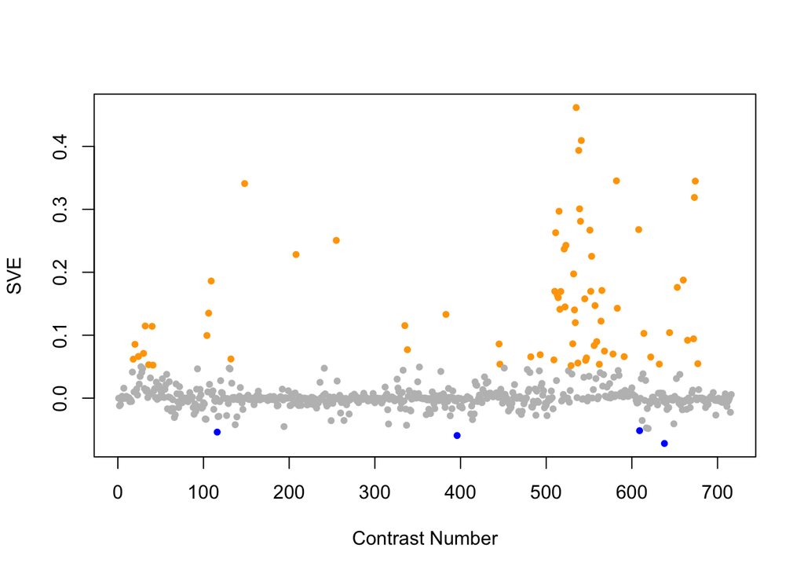

Positive SVE Contrasts:

|  | Contrast.Num | SVE | GEO.GSE | Cond.1 | Cond.2 | Mutation |
| --- | --- | --- | --- | --- | --- | --- |
| GSE2180.s4t10.vs.s1t10 | 535 | 0.46 | GSE2180 | pp186-1 | 186-1 | pie-1(zu154);pal-1(RNAi) |
| GSE2180.s4t2.vs.s1t2 | 541 | 0.41 | GSE2180 | pp23-1 | 23-1 | pie-1(zu154);pal-1(RNAi) |
| GSE2180.s4t10.vs.s3t10 | 538 | 0.39 | GSE2180 | pp186-1 | p186-2 | pal-1(RNAi) |
| GSE2180.s2t2.vs.s2t1 | 582 | 0.35 | GSE2180 | ms23-1 | ms0-1 |  |
| GSE14640C.s1t1.vs.s0t1 | 674 | 0.34 | GSE14640 | XX_SDC2Y93R-P-022208_A | XX_WT-P_081407_A |  |
| GSE48347.s2t1.vs.s0t1 | 148 | 0.34 | GSE48347 | sdc2_embryo_rep1 | WT_embryo_rep1 | sdc-2 |
| GSE14640B.s1t1.vs.s0t1 | 673 | 0.32 | GSE14640 | XX_DPY27-N_042807_A | XX_WT-N_080307_A |  |
| GSE2180.s2t2.vs.s1t2 | 539 | 0.30 | GSE2180 | ms23-1 | 23-1 | mex-3(zu155);skn-1(RNAi) |
| GSE2180.s2t7.vs.s1t7 | 515 | 0.30 | GSE2180 | ms101-2 | 101G | mex-3(zu155);skn-1(RNAi) |
| GSE2180.s3t2.vs.s1t2 | 540 | 0.28 | GSE2180 | p23-2 | 23-1 | pie-1(zu154) |
| GSE21747.s1t1.vs.s0t1 | 608 | 0.27 | GSE21747 | albendazole exposure, biological rep 1 | no albendazole exposure, biological rep 1 |  |
| GSE2180.s2t4.vs.s1t4 | 551 | 0.27 | GSE2180 | ms53-4 | 53-1 | mex-3(zu155);skn-1(RNAi) |
| GSE2180.s4t1.vs.s1t1 | 511 | 0.26 | GSE2180 | pp0-1 | 00B | pie-1(zu154);pal-1(RNAi) |
| GSE41486.s2t1.vs.s1t1 | 255 | 0.25 | GSE41486 | C. elegans grown without a-SWCNT treatment for 48 hr at 22°C. | C. elegans exposed to 500 μg/mL of a-SWCNT for 48 hr at 22°C. |  |
| GSE2180.s4t8.vs.s1t8 | 523 | 0.24 | GSE2180 | pp122-1 | 122-1 | pie-1(zu154);pal-1(RNAi) |
| GSE2180.s2t8.vs.s1t8 | 521 | 0.24 | GSE2180 | ms122-1 | 122-1 | mex-3(zu155);skn-1(RNAi) |
| GSE42703.s2t2.vs.s2t1 | 208 | 0.23 | GSE42703 | WT incubated with H2O, biological rep1 | WT incubated with 1mM copper sulfate, biological rep1 |  |
| GSE2180.s4t4.vs.s1t4 | 553 | 0.23 | GSE2180 | pp53-1 | 53-1 | pie-1(zu154);pal-1(RNAi) |
| GSE2180.s4t9.vs.s3t9 | 532 | 0.20 | GSE2180 | pp143-1 | p143-2 | pal-1(RNAi) |
| GSE15527.s2t1.vs.s1t1 | 660 | 0.19 | GSE15527 | sma-6 L4 worm, biological rep1 | dbl-1 L4 worm, biological rep1 | dbl-1 |
| GSE54513.s4t1.vs.s2t1 | 109 | 0.19 | GSE54513 | spe-9 OMA-1 IP rep1 | fog-1 OMA-1 IP rep1 |  |
| GSE16405.s4t1.vs.s2t1 | 653 | 0.18 | GSE16405 | xpa-1_1 | nth-1_1 | nth-1 vs. xpa-1 |
| GSE2180.s4t6.vs.s1t6 | 565 | 0.17 | GSE2180 | pp83-1 | 83-1 | pie-1(zu154);pal-1(RNAi) |
| GSE2180.s3t1.vs.s1t1 | 510 | 0.17 | GSE2180 | p0-3 | 00B | pie-1(zu154) |
| GSE2180.s3t4.vs.s1t4 | 552 | 0.17 | GSE2180 | p53-2 | 53-1 | pie-1(zu154) |
| GSE2180.s4t7.vs.s1t7 | 517 | 0.17 | GSE2180 | pp101-1 | 101G | pie-1(zu154);pal-1(RNAi) |
| GSE2180.s4t1.vs.s2t1 | 513 | 0.16 | GSE2180 | pp0-1 | ms0-1 |  |
| GSE2180.s4t1.vs.s3t1 | 514 | 0.16 | GSE2180 | pp0-1 | p0-3 | pal-1(RNAi) |
| GSE2180.s2t3.vs.s1t3 | 545 | 0.16 | GSE2180 | ms41-1 | 41D | mex-3(zu155);skn-1(RNAi) |
| GSE2180.s2t5.vs.s1t5 | 557 | 0.15 | GSE2180 | ms66-3 | 66-4 | mex-3(zu155);skn-1(RNAi) |
| GSE2180.s3t8.vs.s1t8 | 522 | 0.14 | GSE2180 | p122-2 | 122-1 | pie-1(zu154) |
| GSE2180.s2t3.vs.s2t1 | 583 | 0.14 | GSE2180 | ms41-1 | ms0-1 |  |
| GSE2180.s3t7.vs.s1t7 | 516 | 0.14 | GSE2180 | p101-2 | 101G | pie-1(zu154) |
| GSE2180.s2t10.vs.s1t10 | 533 | 0.14 | GSE2180 | ms186-5 | 186-1 | mex-3(zu155);skn-1(RNAi) |
| GSE54513.s3t1.vs.s1t1 | 106 | 0.14 | GSE54513 | spe-9 input rep1 | fog-1 input rep1 |  |
| GSE34113.s1t1.vs.s0t1 | 383 | 0.13 | GSE34113 | tdp-1(ok803) | wild-type 1 | tdp-1 |
| GSE2180.s3t6.vs.s1t6 | 564 | 0.12 | GSE2180 | p83-2 | 83-1 | pie-1(zu154) |
| GSE2180.s3t10.vs.s1t10 | 534 | 0.12 | GSE2180 | p186-2 | 186-1 | pie-1(zu154) |
| GSE38997.s3t2.vs.s2t2 | 335 | 0.12 | GSE38997 | experiment 4 UVC- and EtBr-exposed samples at 24 h 4eu24 | experiment 4 EtBr-exposed samples at 24 h 4e24 |  |
| GSE9665.s11t2.vs.s0t2 | 32 | 0.11 | GSE9665 | mex-3 unc-120 186 A | mex-3 186 A | unc-120 |
| GSE9665.s11t3.vs.s0t3 | 40 | 0.11 | GSE9665 | mex-3 unc-120 230 A | mex-3 230 A | unc-120 |
| GSE16915.s1t1.vs.s3t1 | 644 | 0.10 | GSE16915 | control sample | bio-electrosprayed sample |  |
| GSE21591.s2t1.vs.s4t1 | 614 | 0.10 | GSE21591 | Input_1 | aMYC_1 |  |
| GSE57664.s1t1.vs.s0t1 | 104 | 0.10 | GSE57664 | TYR treated rep1 | control rep1 |  |
| GSE14640A.s1t1.vs.s0t1 | 672 | 0.09 | GSE14640 | XO_TY2222-E_080307_A | XX_WT-E_080307_A |  |
| GSE15159.s1t2.vs.s1t1 | 665 | 0.09 | GSE15159 | glp-1_UV_2007_rep1 | glp-1_control_2007_rep1 |  |
| GSE2180.s4t5.vs.s1t5 | 559 | 0.09 | GSE2180 | pp66-1 | 66-4 | pie-1(zu154);pal-1(RNAi) |
| GSE2180.s4t9.vs.s2t9 | 531 | 0.09 | GSE2180 | pp143-1 | ms143-2 |  |
| GSE27677B.s0t9.vs.s0t7 | 445 | 0.09 | GSE27677 | N2, Fed 48 h, rep 1 | N2, Fed 24 h, rep 1 |  |
| GSE9665.s9t1.vs.s0t1 | 20 | 0.09 | GSE9665 | mex-3 scrt-1 143 A | mex-3 143 A | scrt-1 |
| GSE2180.s4t4.vs.s3t4 | 556 | 0.08 | GSE2180 | pp53-1 | p53-2 |  |
| GSE38997.s2t1.vs.s1t1 | 338 | 0.08 | GSE38997 | experiment 4 EtBr-exposed samples at 3 h 4e3 | experiment 4 control samples at 3 h 4c3 |  |
| GSE2180.s4t6.vs.s3t6 | 568 | 0.07 | GSE2180 | pp83-1 | p83-2 | pal-1(RNAi) |
| GSE9665.s9t2.vs.s0t2 | 30 | 0.07 | GSE9665 | mex-3 scrt-1 186 A | mex-3 186 A | scrt-1 |
| GSE2180.s2t7.vs.s2t1 | 578 | 0.07 | GSE2180 | ms101-2 | ms0-1 |  |
| GSE23528C.s1t2.vs.s1t1 | 493 | 0.07 | GSE23528 | Adult at T30 in DD, time-series experiment 2 | Adult at T26 in DD, time-series experiment 2 |  |
| GSE9665.s3t2.vs.s0t2 | 24 | 0.07 | GSE9665 | mex-3 hlh-1 186 A | mex-3 186 A | hlh-1 |
| GSE2180.s3t2.vs.s3t1 | 591 | 0.07 | GSE2180 | p23-2 | p0-3 |  |
| GSE23528A.s2t2.vs.s2t1 | 482 | 0.07 | GSE23528 | Adult at T6 in WC, time-series experiment 1 | Adult at T2 in WC, time-series experiment 1 |  |
| GSE21162.s1t1.vs.s0t1 | 622 | 0.07 | GSE21162 | PVD and OLL neurons, biological rep1 | L3/L4 stage whole animal reference, rep1 |  |
| GSE2180.s4t3.vs.s1t3 | 547 | 0.06 | GSE2180 | pp41-1 | 41D | pie-1(zu154);pal-1(RNAi) |
| GSE52064.s1t1.vs.s3t1 | 132 | 0.06 | GSE52064 | wildtype_1 | lin-54_1 | lin-54 |
| GSE9665.s4t1.vs.s0t1 | 18 | 0.06 | GSE9665 | mex-3 hnd-1 143 A | mex-3 143 A | hnd-1 |
| GSE2180.s2t1.vs.s1t1 | 509 | 0.06 | GSE2180 | ms0-1 | 00B | mex-3(zu155);skn-1(RNAi) |
| GSE2180.s3t3.vs.s1t3 | 546 | 0.06 | GSE2180 | p41-2 | 41D | pie-1(zu154) |
| GSE2180.s4t10.vs.s2t10 | 537 | 0.06 | GSE2180 | pp186-1 | ms186-5 |  |
| GSE13258.s2t1.vs.s0t1 | 677 | 0.05 | GSE13258 | rde-4 mutant, biological rep 1 | wild-type, biological rep 1 | rde-4 |
| GSE19310B.s1t2.vs.s1t1 | 632 | 0.05 | GSE19310 | N2 at 200 for 1 hour, rep1 | N2 at 200 for 15min, rep1 |  |
| GSE27401.s2t1.vs.s3t1 | 446 | 0.05 | GSE27401 | Heat Killed C. albicans #1 | C. albicans alive #1 |  |
| GSE2180.s4t5.vs.s3t5 | 562 | 0.05 | GSE2180 | pp66-1 | p66-1 | pal-1(RNAi) |
| GSE9665.s5t3.vs.s0t3 | 36 | 0.05 | GSE9665 | mex-3 lin-26 230 A | mex-3 230 A | lin-26 |
| GSE9665.s12t3.vs.s0t3 | 41 | 0.05 | GSE9665 | mex-3 vab-7 230 A | mex-3 230 A | vab-7 |
| GSE2180.s4t9.vs.s1t9 | 529 | 0.05 | GSE2180 | pp143-1 | 143L | pie-1(zu154);pal-1(RNAi) |

Negative SVE Contrasts:

|  | Contrast.Num | SVE | GEO.GSE | Cond.1 | Cond.2 | Mutation |
| --- | --- | --- | --- | --- | --- | --- |
| GSE18132.s2t1.vs.s0t1 | 638 | -0.07 | GSE18132 | Oga starved L1, biological replicate 1 | WT Starved L1, biological rep1 | oga-1 |
| GSE32031.s1t1.vs.s0t1 | 396 | -0.06 | GSE32031 | Exerimental (nhr-23 RNAi), biological rep1 | Control, biological rep1 | nhr-23 |
| GSE54024.s4t1.vs.s6t1 | 116 | -0.05 | GSE54024 | isp-1(qm150) young adults, biological rep 1 | isp-1(qm150) ced-4(n1162) double mutant young adults, biological rep 1 | ced-4 |
| GSE21591.s4t1.vs.s5t1 | 609 | -0.05 | GSE21591 | aMYC_1 | aFLAG_1 |  |
| GSE21467.s1t1.vs.s0t1 | 619 | -0.05 | GSE21467 | ung-1, biological rep1 | wild type N2, biological rep1 | ung-1 |

$~$

#### Contrast SVE, Down-Regulated Genes Only:

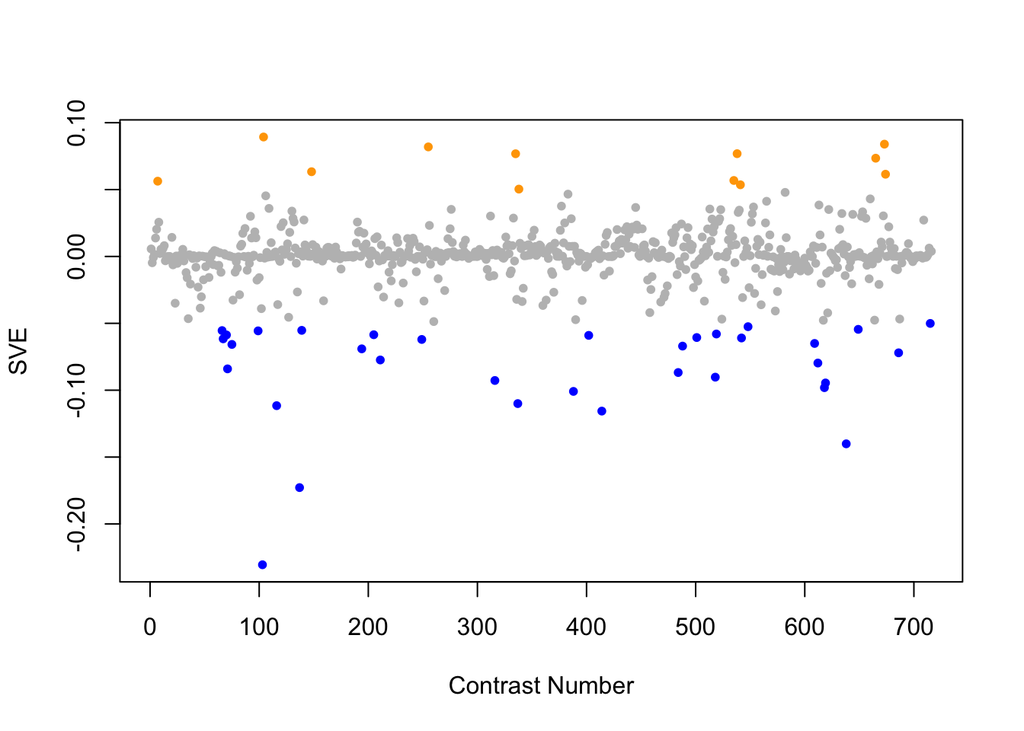

Positive SVE Contrasts:

|  | Contrast.Num | SVE | GEO.GSE | Cond.1 | Cond.2 | Mutation |
| --- | --- | --- | --- | --- | --- | --- |
| GSE57664.s1t1.vs.s0t1 | 104 | 0.09 | GSE57664 | TYR treated rep1 | control rep1 |  |
| GSE14640B.s1t1.vs.s0t1 | 673 | 0.08 | GSE14640 | XX_DPY27-N_042807_A | XX_WT-N_080307_A |  |
| GSE41486.s2t1.vs.s1t1 | 255 | 0.08 | GSE41486 | C. elegans grown without a-SWCNT treatment for 48 hr at 22°C. | C. elegans exposed to 500 μg/mL of a-SWCNT for 48 hr at 22°C. |  |
| GSE2180.s4t10.vs.s3t10 | 538 | 0.08 | GSE2180 | pp186-1 | p186-2 | pal-1(RNAi) |
| GSE38997.s3t2.vs.s2t2 | 335 | 0.08 | GSE38997 | experiment 4 UVC- and EtBr-exposed samples at 24 h 4eu24 | experiment 4 EtBr-exposed samples at 24 h 4e24 |  |
| GSE15159.s1t2.vs.s1t1 | 665 | 0.07 | GSE15159 | glp-1_UV_2007_rep1 | glp-1_control_2007_rep1 |  |
| GSE48347.s2t1.vs.s0t1 | 148 | 0.06 | GSE48347 | sdc2_embryo_rep1 | WT_embryo_rep1 | sdc-2 |
| GSE14640C.s1t1.vs.s0t1 | 674 | 0.06 | GSE14640 | XX_SDC2Y93R-P-022208_A | XX_WT-P_081407_A |  |
| GSE2180.s4t10.vs.s1t10 | 535 | 0.06 | GSE2180 | pp186-1 | 186-1 | pie-1(zu154);pal-1(RNAi) |
| GSE9897B.s4t1.vs.s0t1 | 7 | 0.06 | GSE9897 | Complex I RNAi Mutant 4 | Wildtype (control for RNAi) | Y56A3A.19 |
| GSE2180.s4t2.vs.s1t2 | 541 | 0.05 | GSE2180 | pp23-1 | 23-1 | pie-1(zu154);pal-1(RNAi) |
| GSE38997.s2t1.vs.s1t1 | 338 | 0.05 | GSE38997 | experiment 4 EtBr-exposed samples at 3 h 4e3 | experiment 4 control samples at 3 h 4c3 |  |

Negative SVE Contrasts:

|  | Contrast.Num | SVE | GEO.GSE | Cond.1 | Cond.2 | Mutation |
| --- | --- | --- | --- | --- | --- | --- |
| GSE5793.s3t2.vs.s3t1 | 103 | -0.23 | GSE5793 | Celegans_PA14_8hours_RepA | Celegans_PA14_4hours_RepA |  |
| GSE51691.s3t1.vs.s1t1 | 137 | -0.17 | GSE51691 | day8 hermaphrodite utx-1 RNAi -males rep 1 | day8 hermaphrodite -males rep 1 | utx-1(RNAi) |
| GSE18132.s2t1.vs.s0t1 | 638 | -0.14 | GSE18132 | Oga starved L1, biological replicate 1 | WT Starved L1, biological rep1 | oga-1 |
| GSE29951.s1t1.vs.s0t1 | 414 | -0.12 | GSE29951 | C.elegans MT KO mtl-1,mtl-2(zs1), raised in the absence of Cd, rep1 | C.elegans wild type raised in the absence of Cd, rep1 | mtl-1;mtl-2 |
| GSE54024.s4t1.vs.s6t1 | 116 | -0.11 | GSE54024 | isp-1(qm150) young adults, biological rep 1 | isp-1(qm150) ced-4(n1162) double mutant young adults, biological rep 1 | ced-4 |
| GSE38997.s4t2.vs.s3t2 | 337 | -0.11 | GSE38997 | experiment 4 UVC-exposed samples at 24 h 4u24 | experiment 4 UVC- and EtBr-exposed samples at 24 h 4eu24 |  |
| GSE32949.s1t1.vs.s0t1 | 388 | -0.10 | GSE32949 | C. elegans exposed to space condition, technical rep1 | C. elegans ground control, technical rep1 |  |
| GSE21591.s1t1.vs.s2t1 | 618 | -0.10 | GSE21591 | N2_aFLAG_1 | Input_1 |  |
| GSE21467.s1t1.vs.s0t1 | 619 | -0.09 | GSE21467 | ung-1, biological rep1 | wild type N2, biological rep1 | ung-1 |
| GSE39252.s1t1.vs.s0t1 | 316 | -0.09 | GSE39252 | xpa-1_rep1 | N2_rep1 | xpa-1 |
| GSE2180.s3t7.vs.s2t7 | 518 | -0.09 | GSE2180 | p101-2 | ms101-2 |  |
| GSE23528A.s0t4.vs.s0t1 | 484 | -0.09 | GSE23528 | Adult at T14, non-entrained control time-series experiment 4 | Adult at T2, non-entrained control time-series experiment 4 |  |
| GSE8462.s2t2.vs.s2t1 | 71 | -0.08 | GSE8462 | 24 hr Reference, biological rep 1 | 0 hr Reference, biological rep 1 |  |
| GSE21591.s1t1.vs.s5t1 | 612 | -0.08 | GSE21591 | N2_aFLAG_1 | aFLAG_1 |  |
| GSE42689.s4t1.vs.s1t1 | 211 | -0.08 | GSE42689 | mlk-1 fed 1 | mek-1 fasted 1 |  |
| GSE12298C.s1t1.vs.s0t1 | 686 | -0.07 | GSE12298 | mefloquine_low_dose-rep1 | mefloquine_control-rep1 |  |
| GSE44318.s1t1.vs.s0t1 | 194 | -0.07 | GSE44318 | 13L peptide [SL12] | NGM [SL1] |  |
| GSE23528B.s1t2.vs.s1t1 | 488 | -0.07 | GSE23528 | Adult at T30 in CC, time-series experiment 3 | Adult at T26 in CC, time-series experiment 3 |  |
| GSE8159.s2t1.vs.s1t1 | 75 | -0.07 | GSE8159 | Embryonic Reference, biological rep 1 | Embryonic A-class, biological rep 1 |  |
| GSE21591.s4t1.vs.s5t1 | 609 | -0.07 | GSE21591 | aMYC_1 | aFLAG_1 |  |
| GSE42192.s2t2.vs.s0t2 | 249 | -0.06 | GSE42192 | C.elegans fed with CNCM I-4317 10 days rep1 | C.elegans fed with E.coli OP50 10 days rep1 |  |
| GSE8659.s3t1.vs.s2t1 | 67 | -0.06 | GSE8659 | strain NL 2099 replicate 2 | strain GR1373 replicate 1 |  |
| GSE2180.s3t2.vs.s2t2 | 542 | -0.06 | GSE2180 | p23-2 | ms23-1 |  |
| GSE23013.s1t1.vs.s0t1 | 501 | -0.06 | GSE23013 | young adult_24hr Toluene exposure_rep1 | young adult_not exposed_rep1 |  |
| GSE30505.s1t2.vs.s2t2 | 402 | -0.06 | GSE30505 | Day 8 N2 (WT) E.V. #1 | Day 8 N2 (WT) ash-2 #1 | ash-2 |
| GSE8462.s1t2.vs.s1t1 | 70 | -0.06 | GSE8462 | 24 hr muscle, biological rep 1 | 0 hr muscle, biological rep 1 |  |
| GSE42703.s2t1.vs.s1t1 | 205 | -0.06 | GSE42703 | WT incubated with 1mM copper sulfate, biological rep1 | kgb-1 incubated with 1mM copper sulfate, biological rep1 | kgb-1 |
| GSE2180.s4t7.vs.s2t7 | 519 | -0.06 | GSE2180 | pp101-1 | ms101-2 |  |
| GSE5793.s3t2.vs.s1t2 | 99 | -0.06 | GSE5793 | Celegans_PA14_8hours_RepA | Celegans_gacA_8hours_RepA |  |
| GSE8659.s3t1.vs.s1t1 | 66 | -0.06 | GSE8659 | strain NL 2099 replicate 2 | N2 replicate 1 | rrf-3 |
| GSE51691.s3t1.vs.s2t1 | 139 | -0.06 | GSE51691 | day8 hermaphrodite utx-1 RNAi -males rep 1 | day8 hermaphrodite +males rep 1 |  |
| GSE16405.s2t1.vs.s1t1 | 649 | -0.05 | GSE16405 | nth-1_1 | N2_1 | nth-1 |
| GSE2180.s3t3.vs.s2t3 | 548 | -0.05 | GSE2180 | p41-2 | ms41-1 |  |
| GSE10787A.s1t1.vs.s0t1 | 715 | -0.05 | GSE10787 | Depomerai_heat_shock_1 | Depomerai_heat_control_1 |  |

$~$

$~$

#### GO Term Enrichment:

This analysis tests each hemi-module for enrichment of specific GO terms. Only gene-level annotations (e.g., as would be found on the gene’s page in Wormbase) are tested - the hierarchical structure of the GO ontology is not taken into account.

*Note: At least the top two most enriched terms from each GO domain (BP/MF/CC) are shown, even when not statistically significant.*

##### Enriched GO terms: Hemi-module A

| ID | GO.Term | GO Domain | Raw p-value | Adj p-value |
| --- | --- | --- | --- | --- |
| [GO_0009792](http://amigo.geneontology.org/amigo/term/GO:0009792) | embryo development ending in birth or egg hatching | BP | 1.10e-31 | 4.02e-28 |
| [GO_0002119](http://amigo.geneontology.org/amigo/term/GO:0002119) | nematode larval development | BP | 2.42e-20 | 4.41e-17 |
| [GO_0007275](http://amigo.geneontology.org/amigo/term/GO:0007275) | multicellular organism development | BP | 8.63e-17 | 1.05e-13 |
| [GO_0008340](http://amigo.geneontology.org/amigo/term/GO:0008340) | determination of adult lifespan | BP | 5.52e-16 | 5.02e-13 |
| [GO_0016310](http://amigo.geneontology.org/amigo/term/GO:0016310) | phosphorylation | BP | 2.83e-14 | 2.06e-11 |
| [GO_0007186](http://amigo.geneontology.org/amigo/term/GO:0007186) | G protein-coupled receptor signaling pathway | BP | 1.88e-12 | 1.14e-09 |
| [GO_0043547](http://amigo.geneontology.org/amigo/term/GO:0043547) | positive regulation of GTPase activity | BP | 1.62e-10 | 8.44e-08 |
| [GO_0000132](http://amigo.geneontology.org/amigo/term/GO:0000132) | establishment of mitotic spindle orientation | BP | 3.82e-10 | 1.60e-07 |
| [GO_0007049](http://amigo.geneontology.org/amigo/term/GO:0007049) | cell cycle | BP | 3.96e-10 | 1.60e-07 |
| [GO_0006468](http://amigo.geneontology.org/amigo/term/GO:0006468) | protein phosphorylation | BP | 4.47e-10 | 1.63e-07 |
| [GO_0000003](http://amigo.geneontology.org/amigo/term/GO:0000003) | reproduction | BP | 1.53e-09 | 5.07e-07 |
| [GO_0051301](http://amigo.geneontology.org/amigo/term/GO:0051301) | cell division | BP | 7.58e-09 | 2.30e-06 |
| [GO_0035556](http://amigo.geneontology.org/amigo/term/GO:0035556) | intracellular signal transduction | BP | 8.37e-09 | 2.35e-06 |
| [GO_0016567](http://amigo.geneontology.org/amigo/term/GO:0016567) | protein ubiquitination | BP | 1.14e-08 | 2.97e-06 |
| [GO_0006886](http://amigo.geneontology.org/amigo/term/GO:0006886) | intracellular protein transport | BP | 1.70e-07 | 4.14e-05 |
| [GO_0006897](http://amigo.geneontology.org/amigo/term/GO:0006897) | endocytosis | BP | 2.31e-07 | 5.23e-05 |
| [GO_0032436](http://amigo.geneontology.org/amigo/term/GO:0032436) | positive regulation of proteasomal ubiquitin-dependent protein catabolic process | BP | 2.44e-07 | 5.23e-05 |
| [GO_0015031](http://amigo.geneontology.org/amigo/term/GO:0015031) | protein transport | BP | 3.59e-07 | 7.27e-05 |
| [GO_0043652](http://amigo.geneontology.org/amigo/term/GO:0043652) | engulfment of apoptotic cell | BP | 8.83e-07 | 1.69e-04 |
| [GO_0046688](http://amigo.geneontology.org/amigo/term/GO:0046688) | response to copper ion | BP | 1.04e-06 | 1.90e-04 |
| [GO_0036498](http://amigo.geneontology.org/amigo/term/GO:0036498) | IRE1-mediated unfolded protein response | BP | 1.16e-06 | 2.02e-04 |
| [GO_0006511](http://amigo.geneontology.org/amigo/term/GO:0006511) | ubiquitin-dependent protein catabolic process | BP | 1.80e-06 | 2.98e-04 |
| [GO_1903358](http://amigo.geneontology.org/amigo/term/GO:1903358) | regulation of Golgi organization | BP | 2.17e-06 | 3.21e-04 |
| [GO_2001137](http://amigo.geneontology.org/amigo/term/GO:2001137) | positive regulation of endocytic recycling | BP | 2.17e-06 | 3.21e-04 |
| [GO_0008104](http://amigo.geneontology.org/amigo/term/GO:0008104) | protein localization | BP | 2.20e-06 | 3.21e-04 |
| [GO_1903356](http://amigo.geneontology.org/amigo/term/GO:1903356) | positive regulation of distal tip cell migration | BP | 3.44e-06 | 4.82e-04 |
| [GO_0016477](http://amigo.geneontology.org/amigo/term/GO:0016477) | cell migration | BP | 3.92e-06 | 5.29e-04 |
| [GO_0050911](http://amigo.geneontology.org/amigo/term/GO:0050911) | detection of chemical stimulus involved in sensory perception of smell | BP | 5.05e-06 | 6.57e-04 |
| [GO_0006457](http://amigo.geneontology.org/amigo/term/GO:0006457) | protein folding | BP | 5.27e-06 | 6.61e-04 |
| [GO_0040001](http://amigo.geneontology.org/amigo/term/GO:0040001) | establishment of mitotic spindle localization | BP | 6.43e-06 | 7.81e-04 |

[output cut: 307 more lines]

##### Enriched GO terms: Hemi-module B

| ID | GO.Term | GO Domain | Raw p-value | Adj p-value |
| --- | --- | --- | --- | --- |
| [GO_0043277](http://amigo.geneontology.org/amigo/term/GO:0043277) | apoptotic cell clearance | BP | 2.99e-03 | 1.00e+00 |
| [GO_0044255](http://amigo.geneontology.org/amigo/term/GO:0044255) | cellular lipid metabolic process | BP | 3.32e-03 | 1.00e+00 |
| [GO_0019904](http://amigo.geneontology.org/amigo/term/GO:0019904) | protein domain specific binding | MF | 1.03e-02 | 1.00e+00 |
| [GO_0000981](http://amigo.geneontology.org/amigo/term/GO:0000981) | DNA-binding transcription factor activity, RNA polymerase II-specific | MF | 3.64e-02 | 1.00e+00 |
| [GO_0031463](http://amigo.geneontology.org/amigo/term/GO:0031463) | Cul3-RING ubiquitin ligase complex | CC | 1.66e-03 | 1.00e+00 |
| [GO_0014069](http://amigo.geneontology.org/amigo/term/GO:0014069) | postsynaptic density | CC | 3.65e-03 | 1.00e+00 |

$~$

$~$

#### Tissue Enrichment:

This analysis tests each hemi-module for enrichment of genes associated with anatomy terms. Negative enrichment scores indicate fewer hemi-module genes than expected by random chance were associated with the anatomy term in question.

##### Enriched tissues: Hemi-module A

| ID | Anatomy.Term | Definition | Raw p-value | Adj p-value |
| --- | --- | --- | --- | --- |
| [WBbt_0003681](https://wormbase.org/species/all/anatomy_term/WBbt:0003681) | pharynx | the feeding organ, a neuro-muscular pump in the head of the animal, used to ingest food, bacteria suspended in liquid, filter them out, grind them up and transport posteriorly into the instestine. | 4.91e-22 | 1.19e-18 |
| [WBbt_0005733](https://wormbase.org/species/all/anatomy_term/WBbt:0005733) | hypodermis | Epidermal layer. | 4.40e-21 | 5.36e-18 |
| [WBbt_0005813](https://wormbase.org/species/all/anatomy_term/WBbt:0005813) | body wall musculature | Longitudinal bands of muscle cells surrounding animal body, with one band running in each quadrant of the body, regulated contraction and relaxation of these muscles cause locomotion. | 1.53e-17 | 1.24e-14 |
| [WBbt_0004017](https://wormbase.org/species/all/anatomy_term/WBbt:0004017) | Cell | a cellular object that consists of subcellular components, expresses genes or functions. | 5.47e-15 | 3.33e-12 |
| [WBbt_0006748](https://wormbase.org/species/all/anatomy_term/WBbt:0006748) | vulva | female genital. | 8.93e-15 | 4.34e-12 |
| [WBbt_0005772](https://wormbase.org/species/all/anatomy_term/WBbt:0005772) | intestine | A chain of very large cuboidal cells forming a wide central lumen in which food arrives from the posterior pharynx, is digested, and from which waste products proceed to the rectum. Intestinal rings f… | 1.27e-12 | 5.16e-10 |
| [WBbt_0005747](https://wormbase.org/species/all/anatomy_term/WBbt:0005747) | reproductive system |  | 1.20e-10 | 4.18e-08 |
| [WBbt_0005741](https://wormbase.org/species/all/anatomy_term/WBbt:0005741) | tail | posterior region, from rectum to the end | 1.81e-10 | 5.11e-08 |
| [WBbt_0005319](https://wormbase.org/species/all/anatomy_term/WBbt:0005319) | spermatheca | an accordion-like tube that contains sperm and is the site of oocyte fertilization. | 1.89e-10 | 5.11e-08 |
| [WBbt_0005300](https://wormbase.org/species/all/anatomy_term/WBbt:0005300) | ventral cord neuron | neuron with cell body associated with the ventral nerve cord. | 2.67e-10 | 6.50e-08 |
| [WBbt_0005175](https://wormbase.org/species/all/anatomy_term/WBbt:0005175) | gonad | organ producing either sperm or ova. | 4.78e-10 | 1.06e-07 |
| [WBbt_0006759](https://wormbase.org/species/all/anatomy_term/WBbt:0006759) | tail neuron | neuron with its cell body situated in the tail, posterior to rectum. | 1.40e-09 | 2.84e-07 |
| [WBbt_0005784](https://wormbase.org/species/all/anatomy_term/WBbt:0005784) | germ line | cell line which early in development becomes differentiated from the remaining somatic cell line, and alone has the potential to undergo meiosis and form gametes. | 3.99e-09 | 7.46e-07 |
| [WBbt_0004506](https://wormbase.org/species/all/anatomy_term/WBbt:0004506) | gon_herm_dtc_P | Posterior distal tip cell, inhibit meiosis in neighbouring germ cells, lead gonad during morphogenesis, herm gonad | 4.53e-09 | 7.86e-07 |
| [WBbt_0004520](https://wormbase.org/species/all/anatomy_term/WBbt:0004520) | gon_herm_dtc_A | Anterior distal tip cell, inhibit meiosis in neighbouring germ cells, lead gonad during morphogenesis, herm gonad | 9.03e-09 | 1.47e-06 |
| [WBbt_0006749](https://wormbase.org/species/all/anatomy_term/WBbt:0006749) | nerve ring | the most extensive region of neuropil in the animal, consists of a large toroidal bundle of processes. | 1.67e-08 | 2.53e-06 |
| [WBbt_0005821](https://wormbase.org/species/all/anatomy_term/WBbt:0005821) | vulval muscle | muscle associated with hermaphrodite vulva. | 4.06e-08 | 5.81e-06 |
| [WBbt_0005735](https://wormbase.org/species/all/anatomy_term/WBbt:0005735) | nervous system | Complement of nervous tissue (neurones, nerves, receptors and support cells) serving to detect, relay and coordinate information about an animal’s internal and external environments and to initiate an… | 4.54e-08 | 6.14e-06 |
| [WBbt_0005828](https://wormbase.org/species/all/anatomy_term/WBbt:0005828) | gonadal sheath cell | five pairs of thin gonadal sheath cells form a single layer covering the germ line component of each arm, each pair occupying a stereotyped position along the gonad proximal-distal axis. | 1.54e-07 | 1.97e-05 |
| [WBbt_0005451](https://wormbase.org/species/all/anatomy_term/WBbt:0005451) | pharyngeal muscle cell | type of cells that make up muscle layers in the pharynx. | 2.00e-07 | 2.43e-05 |
| [WBbt_0005739](https://wormbase.org/species/all/anatomy_term/WBbt:0005739) | head | anterior-most body region containing the pharynx. | 2.25e-07 | 2.61e-05 |
| [WBbt_0005753](https://wormbase.org/species/all/anatomy_term/WBbt:0005753) | seam cell | a group of hypodermal cells that lie along the apical midline of the hypodermis, at the extreme left and right sides between nose and tail | 3.08e-07 | 3.40e-05 |
| [WBbt_0003679](https://wormbase.org/species/all/anatomy_term/WBbt:0003679) | neuron | Major cell type of nervous tissue, specialized for transmission of information in the form of patterns of impulses. | 3.21e-07 | 3.40e-05 |
| [WBbt_0003675](https://wormbase.org/species/all/anatomy_term/WBbt:0003675) | muscle cell | contractile cell that makes up muscle tissue. | 6.14e-06 | 6.23e-04 |
| [WBbt_0008435](https://wormbase.org/species/all/anatomy_term/WBbt:0008435) | uterine epithelial cell | cell of the epithelia of uterus. | 2.50e-05 | 2.43e-03 |
| [WBbt_0005812](https://wormbase.org/species/all/anatomy_term/WBbt:0005812) | excretory cell | H-shaped cell associated with the excretory system, largest cell in C. elegans. | 6.09e-05 | 5.70e-03 |
| [WBbt_0007846](https://wormbase.org/species/all/anatomy_term/WBbt:0007846) | hypodermal cell | primary cell type that forms the hypodermis. | 1.17e-04 | 1.06e-02 |
| [WBbt_0006865](https://wormbase.org/species/all/anatomy_term/WBbt:0006865) | DTC | somatic cell that situates at the tip of a gonad arm. | 1.28e-04 | 1.11e-02 |
| [WBbt_0004522](https://wormbase.org/species/all/anatomy_term/WBbt:0004522) | anchor cell | anchor cell, induces vulva, part of hermaphrodite gonad. | 1.42e-04 | 1.15e-02 |
| [WBbt_0008125](https://wormbase.org/species/all/anatomy_term/WBbt:0008125) | P6.p hermaphrodite |  | 1.42e-04 | 1.15e-02 |
| [WBbt_0005800](https://wormbase.org/species/all/anatomy_term/WBbt:0005800) | rectal epithelium | epithelium connecting intestine and anus. | 2.20e-04 | 1.72e-02 |
| [WBbt_0008121](https://wormbase.org/species/all/anatomy_term/WBbt:0008121) | P5.p hermaphrodite | descendent cell of post-embryonic blast cell P5, posterior, in hermaphrodite. | 2.31e-04 | 1.76e-02 |
| [WBbt_0008129](https://wormbase.org/species/all/anatomy_term/WBbt:0008129) | P7.p hermaphrodite |  | 2.85e-04 | 2.10e-02 |
| [WBbt_0006760](https://wormbase.org/species/all/anatomy_term/WBbt:0006760) | uterus | The organ in which the eggs are developed and protected until laid. | 3.46e-04 | 2.47e-02 |
| [WBbt_0007282](https://wormbase.org/species/all/anatomy_term/WBbt:0007282) | QR.pa | post-embryonic cell of pedigree QR.pa | 4.09e-04 | 2.84e-02 |
| [WBbt_0004292](https://wormbase.org/species/all/anatomy_term/WBbt:0004292) | anal depressor muscle | a single, H-shaped cell which lies just above the anus and connects the roof of the anal canal to the dorsal bodywall; its contractions act to increase the size of the anal opening by lifting the roof… | 4.20e-04 | 2.84e-02 |
| [WBbt_0006774](https://wormbase.org/species/all/anatomy_term/WBbt:0006774) | P5 | The fifth (count from anterior-most) of twelve postembryonic blast cells for ventral cord motorneurons, ventral hypodermis, vulva, male preanal ganglion; ventral hypodermis in L1. | 5.05e-04 | 3.32e-02 |
| [WBbt_0007279](https://wormbase.org/species/all/anatomy_term/WBbt:0007279) | QR.a | post-embryonic cell of pedigree QR.a | 5.69e-04 | 3.65e-02 |
| [WBbt_0008594](https://wormbase.org/species/all/anatomy_term/WBbt:0008594) | neuroblast | A blast cell from which a neuron develops. | 6.18e-04 | 3.82e-02 |
| [WBbt_0006767](https://wormbase.org/species/all/anatomy_term/WBbt:0006767) | vulE | adult vulval toroid cell, E, formed by fusion of precursors of lineage names P6.paal, P6.paar, P6.pppl and P6.pppr. | 6.29e-04 | 3.82e-02 |
| [WBbt_0006751](https://wormbase.org/species/all/anatomy_term/WBbt:0006751) | head neuron | neuron with its cell body situated in the head, excluding the pharynx. | 6.57e-04 | 3.82e-02 |
| [WBbt_0006771](https://wormbase.org/species/all/anatomy_term/WBbt:0006771) | P2 | The second (count from anterior-most) of twelve postembryonic blast cells for ventral cord motorneurons, ventral hypodermis, vulva, male preanal ganglion; ventral hypodermis in L1. | 6.76e-04 | 3.82e-02 |
| [WBbt_0006775](https://wormbase.org/species/all/anatomy_term/WBbt:0006775) | P6 | The sixth (count from anterior-most) of twelve postembryonic blast cells for ventral cord motorneurons, ventral hypodermis, vulva, male preanal ganglion; ventral hypodermis in L1. | 6.76e-04 | 3.82e-02 |
| [WBbt_0006762](https://wormbase.org/species/all/anatomy_term/WBbt:0006762) | vulA | adult vulval toroid cell, A, formed by fusion of precursors of lineage names P5.paaa, P5.paap, P7.pppa and P7.pppp | 7.49e-04 | 4.05e-02 |
| [WBbt_0006764](https://wormbase.org/species/all/anatomy_term/WBbt:0006764) | vulB2 | adult vulval toroid cell, B2. | 7.49e-04 | 4.05e-02 |
| [WBbt_0005792](https://wormbase.org/species/all/anatomy_term/WBbt:0005792) | intestinal cell | any of 20 large epithelial cells which form a tube and are mostly situated as bilaterally symmetric pairs around the tubular lumen. Each of these cell pairs forms an intestinal ring ( II-IX int rings)… | 8.70e-04 | 4.60e-02 |
| [WBbt_0006763](https://wormbase.org/species/all/anatomy_term/WBbt:0006763) | vulB1 | adult vulval toroid cell, B1, formed by fusion of precursors of lineage names P5.papa and P7.ppap. | 9.14e-04 | 4.73e-02 |
| [WBbt_0006772](https://wormbase.org/species/all/anatomy_term/WBbt:0006772) | P3 | The third (count from anterior-most) of twelve postembryonic blast cells for ventral cord motorneurons, ventral hypodermis, vulva, male preanal ganglion; ventral hypodermis in L1. | 1.13e-03 | 5.72e-02 |
| [WBbt_0006768](https://wormbase.org/species/all/anatomy_term/WBbt:0006768) | vulF | adult vulval toroid cell, F, formed by fusion of precursors of lineage names P6.papl, P6.papr, P6.ppal and P6.ppar. | 1.52e-03 | 7.54e-02 |
| [WBbt_0006750](https://wormbase.org/species/all/anatomy_term/WBbt:0006750) | dorsal nerve cord | a bundle of nerve processes that runs along the dorsal mid-line of the animal. | 1.88e-03 | 9.13e-02 |
| [WBbt_0006770](https://wormbase.org/species/all/anatomy_term/WBbt:0006770) | P1 | The first (count from anterior-most) of twelve postembryonic blast cells for ventral cord motorneurons, ventral hypodermis, vulva, male preanal ganglion; ventral hypodermis in L1. | 1.94e-03 | 9.26e-02 |
| [WBbt_0005773](https://wormbase.org/species/all/anatomy_term/WBbt:0005773) | rectum | The passage from the posterior intestine, from the rectal valve to the opening to the exterior. | 2.13e-03 | 9.96e-02 |

##### Enriched tissues: Hemi-module B

No significant annotations.

$~$

$~$

#### HOMER promoter motif enrichment:

This analysis tests each hemi-module for enrichment of 108 known *C. elegans* transcription factor binding site motifs (see [108 CE motifs](https://katiepod.github.io//all.worm.motifs.html)) using the HOMER (Hypergeometric Optimization of Motif EnRichment) software (see [PMID:20513432](https://pubmed.ncbi.nlm.nih.gov/20513432)). HOMER was run using default parameters on sequences 1 kb upstream of the transcription start site.

##### Motif enrichment: Hemi-module A

Total target sequences = 956  
Total background sequences = 37978  
* - possible false positive

Rank

Motif

P-value

log P-pvalue

% of Targets

% of Background

STD(Bg STD)

Best Match/Details

Motif File

1

[figure not shown]

1e-32

-7.436e+01

58.47%

39.07%

275.2bp (350.7bp)

eor-1/MA0543.1/Jaspar(0.806)  
[More Information](https://katiepod.github.io/HomerResults/m194_a_hemi_genes.txt.out.1kb/homerResults/motif1.info.html) | [Similar Motifs Found](https://katiepod.github.io/HomerResults/m194_a_hemi_genes.txt.out.1kb/homerResults/motif1.similar.html)

[motif file (matrix)](https://katiepod.github.io/HomerResults/m194_a_hemi_genes.txt.out.1kb/homerResults/motif1.motif)

2

[figure not shown]

1e-28

-6.619e+01

74.06%

56.30%

290.7bp (334.6bp)

blmp-1/MA0537.1/Jaspar(0.709)  
[More Information](https://katiepod.github.io/HomerResults/m194_a_hemi_genes.txt.out.1kb/homerResults/motif2.info.html) | [Similar Motifs Found](https://katiepod.github.io/HomerResults/m194_a_hemi_genes.txt.out.1kb/homerResults/motif2.similar.html)

[motif file (matrix)](https://katiepod.github.io/HomerResults/m194_a_hemi_genes.txt.out.1kb/homerResults/motif2.motif)

3

[figure not shown]

1e-24

-5.538e+01

41.32%

25.86%

278.9bp (356.3bp)

ceh-28/MA1445.1/Jaspar(0.824)  
[More Information](https://katiepod.github.io/HomerResults/m194_a_hemi_genes.txt.out.1kb/homerResults/motif3.info.html) | [Similar Motifs Found](https://katiepod.github.io/HomerResults/m194_a_hemi_genes.txt.out.1kb/homerResults/motif3.similar.html)

[motif file (matrix)](https://katiepod.github.io/HomerResults/m194_a_hemi_genes.txt.out.1kb/homerResults/motif3.motif)

4

[figure not shown]

1e-23

-5.484e+01

36.72%

21.99%

276.9bp (354.3bp)

eor-1/MA0543.1/Jaspar(0.808)  
[More Information](https://katiepod.github.io/HomerResults/m194_a_hemi_genes.txt.out.1kb/homerResults/motif4.info.html) | [Similar Motifs Found](https://katiepod.github.io/HomerResults/m194_a_hemi_genes.txt.out.1kb/homerResults/motif4.similar.html)

[motif file (matrix)](https://katiepod.github.io/HomerResults/m194_a_hemi_genes.txt.out.1kb/homerResults/motif4.motif)

5

[figure not shown]

1e-21

-5.002e+01

51.88%

36.26%

291.8bp (353.0bp)

elt-2/MA1701.1/Jaspar(0.652)  
[More Information](https://katiepod.github.io/HomerResults/m194_a_hemi_genes.txt.out.1kb/homerResults/motif5.info.html) | [Similar Motifs Found](https://katiepod.github.io/HomerResults/m194_a_hemi_genes.txt.out.1kb/homerResults/motif5.similar.html)

[motif file (matrix)](https://katiepod.github.io/HomerResults/m194_a_hemi_genes.txt.out.1kb/homerResults/motif5.motif)

6

[figure not shown]

1e-19

-4.551e+01

55.33%

40.31%

291.5bp (348.9bp)

lin-14/MA0261.1/Jaspar(0.622)  
[More Information](https://katiepod.github.io/HomerResults/m194_a_hemi_genes.txt.out.1kb/homerResults/motif6.info.html) | [Similar Motifs Found](https://katiepod.github.io/HomerResults/m194_a_hemi_genes.txt.out.1kb/homerResults/motif6.similar.html)

[motif file (matrix)](https://katiepod.github.io/HomerResults/m194_a_hemi_genes.txt.out.1kb/homerResults/motif6.motif)

7

[figure not shown]

1e-19

-4.394e+01

50.42%

35.87%

284.6bp (345.7bp)

SD0002.1_at_AC_acceptor/Jaspar(0.605)  
[More Information](https://katiepod.github.io/HomerResults/m194_a_hemi_genes.txt.out.1kb/homerResults/motif7.info.html) | [Similar Motifs Found](https://katiepod.github.io/HomerResults/m194_a_hemi_genes.txt.out.1kb/homerResults/motif7.similar.html)

[motif file (matrix)](https://katiepod.github.io/HomerResults/m194_a_hemi_genes.txt.out.1kb/homerResults/motif7.motif)

8

[figure not shown]

1e-18

-4.175e+01

30.02%

18.09%

271.2bp (370.0bp)

PL0008.1_hlh-29/Jaspar(0.677)  
[More Information](https://katiepod.github.io/HomerResults/m194_a_hemi_genes.txt.out.1kb/homerResults/motif8.info.html) | [Similar Motifs Found](https://katiepod.github.io/HomerResults/m194_a_hemi_genes.txt.out.1kb/homerResults/motif8.similar.html)

[motif file (matrix)](https://katiepod.github.io/HomerResults/m194_a_hemi_genes.txt.out.1kb/homerResults/motif8.motif)

9

[figure not shown]

1e-17

-4.137e+01

36.09%

23.29%

284.8bp (352.4bp)

daf-12/MA0538.1/Jaspar(0.822)  
[More Information](https://katiepod.github.io/HomerResults/m194_a_hemi_genes.txt.out.1kb/homerResults/motif9.info.html) | [Similar Motifs Found](https://katiepod.github.io/HomerResults/m194_a_hemi_genes.txt.out.1kb/homerResults/motif9.similar.html)

[motif file (matrix)](https://katiepod.github.io/HomerResults/m194_a_hemi_genes.txt.out.1kb/homerResults/motif9.motif)

10

[figure not shown]

1e-17

-4.128e+01

26.78%

15.51%

284.3bp (356.8bp)

MF0002.1_bZIP_CREB/G-box-like_subclass/Jaspar(0.522)  
[More Information](https://katiepod.github.io/HomerResults/m194_a_hemi_genes.txt.out.1kb/homerResults/motif10.info.html) | [Similar Motifs Found](https://katiepod.github.io/HomerResults/m194_a_hemi_genes.txt.out.1kb/homerResults/motif10.similar.html)

[motif file (matrix)](https://katiepod.github.io/HomerResults/m194_a_hemi_genes.txt.out.1kb/homerResults/motif10.motif)

11

[figure not shown]

1e-16

-3.787e+01

17.47%

8.75%

280.7bp (347.3bp)

cebp-1/MA1444.1/Jaspar(0.855)  
[More Information](https://katiepod.github.io/HomerResults/m194_a_hemi_genes.txt.out.1kb/homerResults/motif11.info.html) | [Similar Motifs Found](https://katiepod.github.io/HomerResults/m194_a_hemi_genes.txt.out.1kb/homerResults/motif11.similar.html)

[motif file (matrix)](https://katiepod.github.io/HomerResults/m194_a_hemi_genes.txt.out.1kb/homerResults/motif11.motif)

12

[figure not shown]

1e-15

-3.532e+01

31.49%

20.24%

297.8bp (343.7bp)

elt-2/MA1701.1/Jaspar(0.589)  
[More Information](https://katiepod.github.io/HomerResults/m194_a_hemi_genes.txt.out.1kb/homerResults/motif12.info.html) | [Similar Motifs Found](https://katiepod.github.io/HomerResults/m194_a_hemi_genes.txt.out.1kb/homerResults/motif12.similar.html)

[motif file (matrix)](https://katiepod.github.io/HomerResults/m194_a_hemi_genes.txt.out.1kb/homerResults/motif12.motif)

13

[figure not shown]

1e-13

-3.120e+01

3.66%

0.70%

265.2bp (310.9bp)

fos-1/MA1448.1/Jaspar(0.728)  
[More Information](https://katiepod.github.io/HomerResults/m194_a_hemi_genes.txt.out.1kb/homerResults/motif13.info.html) | [Similar Motifs Found](https://katiepod.github.io/HomerResults/m194_a_hemi_genes.txt.out.1kb/homerResults/motif13.similar.html)

[motif file (matrix)](https://katiepod.github.io/HomerResults/m194_a_hemi_genes.txt.out.1kb/homerResults/motif13.motif)

14

[figure not shown]

1e-13

-3.000e+01

4.81%

1.25%

225.6bp (363.6bp)

POL003.1_GC-box/Jaspar(0.581)  
[More Information](https://katiepod.github.io/HomerResults/m194_a_hemi_genes.txt.out.1kb/homerResults/motif14.info.html) | [Similar Motifs Found](https://katiepod.github.io/HomerResults/m194_a_hemi_genes.txt.out.1kb/homerResults/motif14.similar.html)

[motif file (matrix)](https://katiepod.github.io/HomerResults/m194_a_hemi_genes.txt.out.1kb/homerResults/motif14.motif)

15

[figure not shown]

1e-12

-2.904e+01

19.56%

11.34%

293.5bp (346.0bp)

POL002.1_INR/Jaspar(0.557)  
[More Information](https://katiepod.github.io/HomerResults/m194_a_hemi_genes.txt.out.1kb/homerResults/motif15.info.html) | [Similar Motifs Found](https://katiepod.github.io/HomerResults/m194_a_hemi_genes.txt.out.1kb/homerResults/motif15.similar.html)

[motif file (matrix)](https://katiepod.github.io/HomerResults/m194_a_hemi_genes.txt.out.1kb/homerResults/motif15.motif)

16 *

[figure not shown]

1e-11

-2.748e+01

2.41%

0.32%

318.3bp (325.8bp)

mab-3/MA0262.1/Jaspar(0.552)  
[More Information](https://katiepod.github.io/HomerResults/m194_a_hemi_genes.txt.out.1kb/homerResults/motif16.info.html) | [Similar Motifs Found](https://katiepod.github.io/HomerResults/m194_a_hemi_genes.txt.out.1kb/homerResults/motif16.similar.html)

[motif file (matrix)](https://katiepod.github.io/HomerResults/m194_a_hemi_genes.txt.out.1kb/homerResults/motif16.motif)

17 *

[figure not shown]

1e-11

-2.601e+01

3.97%

0.99%

225.4bp (327.7bp)

lin-14/MA0261.1/Jaspar(0.632)  
[More Information](https://katiepod.github.io/HomerResults/m194_a_hemi_genes.txt.out.1kb/homerResults/motif17.info.html) | [Similar Motifs Found](https://katiepod.github.io/HomerResults/m194_a_hemi_genes.txt.out.1kb/homerResults/motif17.similar.html)

[motif file (matrix)](https://katiepod.github.io/HomerResults/m194_a_hemi_genes.txt.out.1kb/homerResults/motif17.motif)

18 *

[figure not shown]

1e-11

-2.567e+01

1.57%

0.11%

264.3bp (350.2bp)

MF0002.1_bZIP_CREB/G-box-like_subclass/Jaspar(0.600)  
[More Information](https://katiepod.github.io/HomerResults/m194_a_hemi_genes.txt.out.1kb/homerResults/motif18.info.html) | [Similar Motifs Found](https://katiepod.github.io/HomerResults/m194_a_hemi_genes.txt.out.1kb/homerResults/motif18.similar.html)

[motif file (matrix)](https://katiepod.github.io/HomerResults/m194_a_hemi_genes.txt.out.1kb/homerResults/motif18.motif)

19 *

[figure not shown]

1e-10

-2.506e+01

3.66%

0.88%

266.6bp (345.6bp)

ces-2/MA0922.1/Jaspar(0.623)  
[More Information](https://katiepod.github.io/HomerResults/m194_a_hemi_genes.txt.out.1kb/homerResults/motif19.info.html) | [Similar Motifs Found](https://katiepod.github.io/HomerResults/m194_a_hemi_genes.txt.out.1kb/homerResults/motif19.similar.html)

[motif file (matrix)](https://katiepod.github.io/HomerResults/m194_a_hemi_genes.txt.out.1kb/homerResults/motif19.motif)

20 *

[figure not shown]

1e-10

-2.458e+01

5.13%

1.65%

255.4bp (345.8bp)

POL003.1_GC-box/Jaspar(0.683)  
[More Information](https://katiepod.github.io/HomerResults/m194_a_hemi_genes.txt.out.1kb/homerResults/motif20.info.html) | [Similar Motifs Found](https://katiepod.github.io/HomerResults/m194_a_hemi_genes.txt.out.1kb/homerResults/motif20.similar.html)

[motif file (matrix)](https://katiepod.github.io/HomerResults/m194_a_hemi_genes.txt.out.1kb/homerResults/motif20.motif)

21 *

[figure not shown]

1e-10

-2.411e+01

2.93%

0.59%

256.7bp (380.2bp)

ceh-22/MA0264.1/Jaspar(0.562)  
[More Information](https://katiepod.github.io/HomerResults/m194_a_hemi_genes.txt.out.1kb/homerResults/motif21.info.html) | [Similar Motifs Found](https://katiepod.github.io/HomerResults/m194_a_hemi_genes.txt.out.1kb/homerResults/motif21.similar.html)

[motif file (matrix)](https://katiepod.github.io/HomerResults/m194_a_hemi_genes.txt.out.1kb/homerResults/motif21.motif)

22 *

[figure not shown]

1e-10

-2.355e+01

2.93%

0.60%

242.1bp (363.1bp)

dpy-27/MA0540.1/Jaspar(0.688)  
[More Information](https://katiepod.github.io/HomerResults/m194_a_hemi_genes.txt.out.1kb/homerResults/motif22.info.html) | [Similar Motifs Found](https://katiepod.github.io/HomerResults/m194_a_hemi_genes.txt.out.1kb/homerResults/motif22.similar.html)

[motif file (matrix)](https://katiepod.github.io/HomerResults/m194_a_hemi_genes.txt.out.1kb/homerResults/motif22.motif)

23 *

[figure not shown]

1e-9

-2.286e+01

3.77%

1.01%

284.5bp (353.9bp)

ceh-38/MA1699.1/Jaspar(0.645)  
[More Information](https://katiepod.github.io/HomerResults/m194_a_hemi_genes.txt.out.1kb/homerResults/motif23.info.html) | [Similar Motifs Found](https://katiepod.github.io/HomerResults/m194_a_hemi_genes.txt.out.1kb/homerResults/motif23.similar.html)

[motif file (matrix)](https://katiepod.github.io/HomerResults/m194_a_hemi_genes.txt.out.1kb/homerResults/motif23.motif)

24 *

[figure not shown]

1e-9

-2.251e+01

27.20%

18.72%

286.0bp (340.5bp)

PHA-4(Forkhead)/cElegans-Embryos-PHA4-ChIP-Seq(modEncode)/Homer(0.679)  
[More Information](https://katiepod.github.io/HomerResults/m194_a_hemi_genes.txt.out.1kb/homerResults/motif24.info.html) | [Similar Motifs Found](https://katiepod.github.io/HomerResults/m194_a_hemi_genes.txt.out.1kb/homerResults/motif24.similar.html)

[motif file (matrix)](https://katiepod.github.io/HomerResults/m194_a_hemi_genes.txt.out.1kb/homerResults/motif24.motif)

25 *

[figure not shown]

1e-9

-2.219e+01

2.51%

0.47%

241.4bp (370.5bp)

fkh-9/MA1440.1/Jaspar(0.703)  
[More Information](https://katiepod.github.io/HomerResults/m194_a_hemi_genes.txt.out.1kb/homerResults/motif25.info.html) | [Similar Motifs Found](https://katiepod.github.io/HomerResults/m194_a_hemi_genes.txt.out.1kb/homerResults/motif25.similar.html)

[motif file (matrix)](https://katiepod.github.io/HomerResults/m194_a_hemi_genes.txt.out.1kb/homerResults/motif25.motif)

26 *

[figure not shown]

1e-9

-2.181e+01

2.20%

0.36%

230.5bp (334.4bp)

POL006.1_BREu/Jaspar(0.740)  
[More Information](https://katiepod.github.io/HomerResults/m194_a_hemi_genes.txt.out.1kb/homerResults/motif26.info.html) | [Similar Motifs Found](https://katiepod.github.io/HomerResults/m194_a_hemi_genes.txt.out.1kb/homerResults/motif26.similar.html)

[motif file (matrix)](https://katiepod.github.io/HomerResults/m194_a_hemi_genes.txt.out.1kb/homerResults/motif26.motif)

27 *

[figure not shown]

1e-9

-2.176e+01

32.53%

23.59%

283.7bp (313.4bp)

ces-2/MA0922.1/Jaspar(0.739)  
[More Information](https://katiepod.github.io/HomerResults/m194_a_hemi_genes.txt.out.1kb/homerResults/motif27.info.html) | [Similar Motifs Found](https://katiepod.github.io/HomerResults/m194_a_hemi_genes.txt.out.1kb/homerResults/motif27.similar.html)

[motif file (matrix)](https://katiepod.github.io/HomerResults/m194_a_hemi_genes.txt.out.1kb/homerResults/motif27.motif)

28 *

[figure not shown]

1e-9

-2.118e+01

7.32%

3.20%

270.0bp (344.7bp)

lin-14/MA0261.1/Jaspar(0.612)  
[More Information](https://katiepod.github.io/HomerResults/m194_a_hemi_genes.txt.out.1kb/homerResults/motif28.info.html) | [Similar Motifs Found](https://katiepod.github.io/HomerResults/m194_a_hemi_genes.txt.out.1kb/homerResults/motif28.similar.html)

[motif file (matrix)](https://katiepod.github.io/HomerResults/m194_a_hemi_genes.txt.out.1kb/homerResults/motif28.motif)

29 *

[figure not shown]

1e-9

-2.117e+01

16.53%

10.02%

260.7bp (342.0bp)

DPL-1(E2F)/cElegans-Adult-ChIP-Seq(modEncode)/Homer(0.668)  
[More Information](https://katiepod.github.io/HomerResults/m194_a_hemi_genes.txt.out.1kb/homerResults/motif29.info.html) | [Similar Motifs Found](https://katiepod.github.io/HomerResults/m194_a_hemi_genes.txt.out.1kb/homerResults/motif29.similar.html)

[motif file (matrix)](https://katiepod.github.io/HomerResults/m194_a_hemi_genes.txt.out.1kb/homerResults/motif29.motif)

30 *

[figure not shown]

1e-8

-1.984e+01

1.36%

0.13%

269.6bp (323.8bp)

lin-14/MA0261.1/Jaspar(0.540)  
[More Information](https://katiepod.github.io/HomerResults/m194_a_hemi_genes.txt.out.1kb/homerResults/motif30.info.html) | [Similar Motifs Found](https://katiepod.github.io/HomerResults/m194_a_hemi_genes.txt.out.1kb/homerResults/motif30.similar.html)

[motif file (matrix)](https://katiepod.github.io/HomerResults/m194_a_hemi_genes.txt.out.1kb/homerResults/motif30.motif)

31 *

[figure not shown]

1e-6

-1.489e+01

0.94%

0.08%

145.5bp (285.7bp)

MF0002.1_bZIP_CREB/G-box-like_subclass/Jaspar(0.761)  
[More Information](https://katiepod.github.io/HomerResults/m194_a_hemi_genes.txt.out.1kb/homerResults/motif31.info.html) | [Similar Motifs Found](https://katiepod.github.io/HomerResults/m194_a_hemi_genes.txt.out.1kb/homerResults/motif31.similar.html)

[motif file (matrix)](https://katiepod.github.io/HomerResults/m194_a_hemi_genes.txt.out.1kb/homerResults/motif31.motif)

32 *

[figure not shown]

1e-5

-1.293e+01

6.90%

3.71%

282.9bp (332.8bp)

MF0010.1_Homeobox_class/Jaspar(0.675)  
[More Information](https://katiepod.github.io/HomerResults/m194_a_hemi_genes.txt.out.1kb/homerResults/motif32.info.html) | [Similar Motifs Found](https://katiepod.github.io/HomerResults/m194_a_hemi_genes.txt.out.1kb/homerResults/motif32.similar.html)

[motif file (matrix)](https://katiepod.github.io/HomerResults/m194_a_hemi_genes.txt.out.1kb/homerResults/motif32.motif)

33 *

[figure not shown]

1e-5

-1.267e+01

9.31%

5.57%

259.9bp (308.3bp)

MF0009.1_TRP(MYB)_class/Jaspar(0.664)  
[More Information](https://katiepod.github.io/HomerResults/m194_a_hemi_genes.txt.out.1kb/homerResults/motif33.info.html) | [Similar Motifs Found](https://katiepod.github.io/HomerResults/m194_a_hemi_genes.txt.out.1kb/homerResults/motif33.similar.html)

[motif file (matrix)](https://katiepod.github.io/HomerResults/m194_a_hemi_genes.txt.out.1kb/homerResults/motif33.motif)

34 *

[figure not shown]

1e-3

-8.858e+00

0.31%

0.01%

209.5bp (59.0bp)

MF0008.1_MADS_class/Jaspar(0.599)  
[More Information](https://katiepod.github.io/HomerResults/m194_a_hemi_genes.txt.out.1kb/homerResults/motif34.info.html) | [Similar Motifs Found](https://katiepod.github.io/HomerResults/m194_a_hemi_genes.txt.out.1kb/homerResults/motif34.similar.html)

[motif file (matrix)](https://katiepod.github.io/HomerResults/m194_a_hemi_genes.txt.out.1kb/homerResults/motif34.motif)

##### Motif enrichment: Hemi-module B

Total target sequences = 6  
Total background sequences = 44000  
* - possible false positive

Rank

Motif

P-value

log P-pvalue

% of Targets

% of Background

STD(Bg STD)

Best Match/Details

Motif File

1 *

[figure not shown]

1e-4

-1.051e+01

33.33%

0.13%

292.5bp (474.1bp)

PL0016.1_ref-1/Jaspar(0.590)  
[More Information](https://katiepod.github.io/HomerResults/m194_b_hemi_genes.txt.out.1kb/homerResults/motif1.info.html) | [Similar Motifs Found](https://katiepod.github.io/HomerResults/m194_b_hemi_genes.txt.out.1kb/homerResults/motif1.similar.html)

[motif file (matrix)](https://katiepod.github.io/HomerResults/m194_b_hemi_genes.txt.out.1kb/homerResults/motif1.motif)

2 *

[figure not shown]

1e-4

-9.554e+00

33.33%

0.22%

134.2bp (246.0bp)

POL008.1_DCE_S_I/Jaspar(0.590)  
[More Information](https://katiepod.github.io/HomerResults/m194_b_hemi_genes.txt.out.1kb/homerResults/motif2.info.html) | [Similar Motifs Found](https://katiepod.github.io/HomerResults/m194_b_hemi_genes.txt.out.1kb/homerResults/motif2.similar.html)

[motif file (matrix)](https://katiepod.github.io/HomerResults/m194_b_hemi_genes.txt.out.1kb/homerResults/motif2.motif)

3 *

[figure not shown]

1e-3

-8.916e+00

16.67%

0.00%

0.0bp (0.0bp)

fkh-9/MA1440.1/Jaspar(0.476)  
[More Information](https://katiepod.github.io/HomerResults/m194_b_hemi_genes.txt.out.1kb/homerResults/motif3.info.html) | [Similar Motifs Found](https://katiepod.github.io/HomerResults/m194_b_hemi_genes.txt.out.1kb/homerResults/motif3.similar.html)

[motif file (matrix)](https://katiepod.github.io/HomerResults/m194_b_hemi_genes.txt.out.1kb/homerResults/motif3.motif)

4 *

[figure not shown]

1e-3

-8.916e+00

16.67%

0.00%

0.0bp (0.0bp)

POL012.1_TATA-Box/Jaspar(0.547)  
[More Information](https://katiepod.github.io/HomerResults/m194_b_hemi_genes.txt.out.1kb/homerResults/motif4.info.html) | [Similar Motifs Found](https://katiepod.github.io/HomerResults/m194_b_hemi_genes.txt.out.1kb/homerResults/motif4.similar.html)

[motif file (matrix)](https://katiepod.github.io/HomerResults/m194_b_hemi_genes.txt.out.1kb/homerResults/motif4.motif)

5 *

[figure not shown]

1e-3

-8.916e+00

16.67%

0.00%

0.0bp (0.0bp)

MF0008.1_MADS_class/Jaspar(0.550)  
[More Information](https://katiepod.github.io/HomerResults/m194_b_hemi_genes.txt.out.1kb/homerResults/motif5.info.html) | [Similar Motifs Found](https://katiepod.github.io/HomerResults/m194_b_hemi_genes.txt.out.1kb/homerResults/motif5.similar.html)

[motif file (matrix)](https://katiepod.github.io/HomerResults/m194_b_hemi_genes.txt.out.1kb/homerResults/motif5.motif)

6 *

[figure not shown]

1e-3

-8.916e+00

16.67%

0.00%

0.0bp (0.0bp)

elt-2/MA1701.1/Jaspar(0.734)  
[More Information](https://katiepod.github.io/HomerResults/m194_b_hemi_genes.txt.out.1kb/homerResults/motif6.info.html) | [Similar Motifs Found](https://katiepod.github.io/HomerResults/m194_b_hemi_genes.txt.out.1kb/homerResults/motif6.similar.html)

[motif file (matrix)](https://katiepod.github.io/HomerResults/m194_b_hemi_genes.txt.out.1kb/homerResults/motif6.motif)

7 *

[figure not shown]

1e-3

-8.916e+00

16.67%

0.00%

0.0bp (0.0bp)

POL013.1_MED-1/Jaspar(0.640)  
[More Information](https://katiepod.github.io/HomerResults/m194_b_hemi_genes.txt.out.1kb/homerResults/motif7.info.html) | [Similar Motifs Found](https://katiepod.github.io/HomerResults/m194_b_hemi_genes.txt.out.1kb/homerResults/motif7.similar.html)

[motif file (matrix)](https://katiepod.github.io/HomerResults/m194_b_hemi_genes.txt.out.1kb/homerResults/motif7.motif)

8 *

[figure not shown]

1e-3

-8.916e+00

16.67%

0.00%

0.0bp (0.0bp)

blmp-1/MA0537.1/Jaspar(0.537)  
[More Information](https://katiepod.github.io/HomerResults/m194_b_hemi_genes.txt.out.1kb/homerResults/motif8.info.html) | [Similar Motifs Found](https://katiepod.github.io/HomerResults/m194_b_hemi_genes.txt.out.1kb/homerResults/motif8.similar.html)

[motif file (matrix)](https://katiepod.github.io/HomerResults/m194_b_hemi_genes.txt.out.1kb/homerResults/motif8.motif)

9 *

[figure not shown]

1e-3

-8.916e+00

16.67%

0.00%

0.0bp (0.0bp)

ceh-22/MA0264.1/Jaspar(0.544)  
[More Information](https://katiepod.github.io/HomerResults/m194_b_hemi_genes.txt.out.1kb/homerResults/motif9.info.html) | [Similar Motifs Found](https://katiepod.github.io/HomerResults/m194_b_hemi_genes.txt.out.1kb/homerResults/motif9.similar.html)

[motif file (matrix)](https://katiepod.github.io/HomerResults/m194_b_hemi_genes.txt.out.1kb/homerResults/motif9.motif)

10 *

[figure not shown]

1e-3

-8.916e+00

16.67%

0.00%

0.0bp (0.0bp)

PL0016.1_ref-1/Jaspar(0.584)  
[More Information](https://katiepod.github.io/HomerResults/m194_b_hemi_genes.txt.out.1kb/homerResults/motif10.info.html) | [Similar Motifs Found](https://katiepod.github.io/HomerResults/m194_b_hemi_genes.txt.out.1kb/homerResults/motif10.similar.html)

[motif file (matrix)](https://katiepod.github.io/HomerResults/m194_b_hemi_genes.txt.out.1kb/homerResults/motif10.motif)

11 *

[figure not shown]

1e-3

-8.916e+00

16.67%

0.00%

0.0bp (0.0bp)

fkh-2/MA0920.1/Jaspar(0.587)  
[More Information](https://katiepod.github.io/HomerResults/m194_b_hemi_genes.txt.out.1kb/homerResults/motif11.info.html) | [Similar Motifs Found](https://katiepod.github.io/HomerResults/m194_b_hemi_genes.txt.out.1kb/homerResults/motif11.similar.html)

[motif file (matrix)](https://katiepod.github.io/HomerResults/m194_b_hemi_genes.txt.out.1kb/homerResults/motif11.motif)

12 *

[figure not shown]

1e-3

-8.916e+00

16.67%

0.00%

0.0bp (0.0bp)

POL012.1_TATA-Box/Jaspar(0.514)  
[More Information](https://katiepod.github.io/HomerResults/m194_b_hemi_genes.txt.out.1kb/homerResults/motif12.info.html) | [Similar Motifs Found](https://katiepod.github.io/HomerResults/m194_b_hemi_genes.txt.out.1kb/homerResults/motif12.similar.html)

[motif file (matrix)](https://katiepod.github.io/HomerResults/m194_b_hemi_genes.txt.out.1kb/homerResults/motif12.motif)

13 *

[figure not shown]

1e-3

-8.916e+00

16.67%

0.00%

0.0bp (0.0bp)

elt-3/MA0542.1/Jaspar(0.512)  
[More Information](https://katiepod.github.io/HomerResults/m194_b_hemi_genes.txt.out.1kb/homerResults/motif13.info.html) | [Similar Motifs Found](https://katiepod.github.io/HomerResults/m194_b_hemi_genes.txt.out.1kb/homerResults/motif13.similar.html)

[motif file (matrix)](https://katiepod.github.io/HomerResults/m194_b_hemi_genes.txt.out.1kb/homerResults/motif13.motif)

14 *

[figure not shown]

1e-3

-8.916e+00

16.67%

0.00%

0.0bp (0.0bp)

POL004.1_CCAAT-box/Jaspar(0.551)  
[More Information](https://katiepod.github.io/HomerResults/m194_b_hemi_genes.txt.out.1kb/homerResults/motif14.info.html) | [Similar Motifs Found](https://katiepod.github.io/HomerResults/m194_b_hemi_genes.txt.out.1kb/homerResults/motif14.similar.html)

[motif file (matrix)](https://katiepod.github.io/HomerResults/m194_b_hemi_genes.txt.out.1kb/homerResults/motif14.motif)

15 *

[figure not shown]

1e-3

-8.916e+00

16.67%

0.00%

0.0bp (0.0bp)

PL0012.1_hlh-2::hlh-8/Jaspar(0.749)  
[More Information](https://katiepod.github.io/HomerResults/m194_b_hemi_genes.txt.out.1kb/homerResults/motif15.info.html) | [Similar Motifs Found](https://katiepod.github.io/HomerResults/m194_b_hemi_genes.txt.out.1kb/homerResults/motif15.similar.html)

[motif file (matrix)](https://katiepod.github.io/HomerResults/m194_b_hemi_genes.txt.out.1kb/homerResults/motif15.motif)

16 *

[figure not shown]

1e-3

-8.916e+00

16.67%

0.00%

0.0bp (0.0bp)

MF0001.1_ETS_class/Jaspar(0.565)  
[More Information](https://katiepod.github.io/HomerResults/m194_b_hemi_genes.txt.out.1kb/homerResults/motif16.info.html) | [Similar Motifs Found](https://katiepod.github.io/HomerResults/m194_b_hemi_genes.txt.out.1kb/homerResults/motif16.similar.html)

[motif file (matrix)](https://katiepod.github.io/HomerResults/m194_b_hemi_genes.txt.out.1kb/homerResults/motif16.motif)

17 *

[figure not shown]

1e-3

-8.916e+00

16.67%

0.00%

0.0bp (0.0bp)

fkh-9/MA1440.1/Jaspar(0.544)  
[More Information](https://katiepod.github.io/HomerResults/m194_b_hemi_genes.txt.out.1kb/homerResults/motif17.info.html) | [Similar Motifs Found](https://katiepod.github.io/HomerResults/m194_b_hemi_genes.txt.out.1kb/homerResults/motif17.similar.html)

[motif file (matrix)](https://katiepod.github.io/HomerResults/m194_b_hemi_genes.txt.out.1kb/homerResults/motif17.motif)

18 *

[figure not shown]

1e-3

-8.916e+00

16.67%

0.00%

0.0bp (0.0bp)

unc-86/MA0926.1/Jaspar(0.600)  
[More Information](https://katiepod.github.io/HomerResults/m194_b_hemi_genes.txt.out.1kb/homerResults/motif18.info.html) | [Similar Motifs Found](https://katiepod.github.io/HomerResults/m194_b_hemi_genes.txt.out.1kb/homerResults/motif18.similar.html)

[motif file (matrix)](https://katiepod.github.io/HomerResults/m194_b_hemi_genes.txt.out.1kb/homerResults/motif18.motif)

19 *

[figure not shown]

1e-3

-8.916e+00

16.67%

0.00%

0.0bp (0.0bp)

POL009.1_DCE_S_II/Jaspar(0.556)  
[More Information](https://katiepod.github.io/HomerResults/m194_b_hemi_genes.txt.out.1kb/homerResults/motif19.info.html) | [Similar Motifs Found](https://katiepod.github.io/HomerResults/m194_b_hemi_genes.txt.out.1kb/homerResults/motif19.similar.html)

[motif file (matrix)](https://katiepod.github.io/HomerResults/m194_b_hemi_genes.txt.out.1kb/homerResults/motif19.motif)

20 *

[figure not shown]

1e-3

-8.916e+00

16.67%

0.00%

0.0bp (0.0bp)

PL0001.1_hlh-11/Jaspar(0.730)  
[More Information](https://katiepod.github.io/HomerResults/m194_b_hemi_genes.txt.out.1kb/homerResults/motif20.info.html) | [Similar Motifs Found](https://katiepod.github.io/HomerResults/m194_b_hemi_genes.txt.out.1kb/homerResults/motif20.similar.html)

[motif file (matrix)](https://katiepod.github.io/HomerResults/m194_b_hemi_genes.txt.out.1kb/homerResults/motif20.motif)

21 *

[figure not shown]

1e-3

-8.916e+00

16.67%

0.00%

0.0bp (0.0bp)

POL001.1_MTE/Jaspar(0.544)  
[More Information](https://katiepod.github.io/HomerResults/m194_b_hemi_genes.txt.out.1kb/homerResults/motif21.info.html) | [Similar Motifs Found](https://katiepod.github.io/HomerResults/m194_b_hemi_genes.txt.out.1kb/homerResults/motif21.similar.html)

[motif file (matrix)](https://katiepod.github.io/HomerResults/m194_b_hemi_genes.txt.out.1kb/homerResults/motif21.motif)

22 *

[figure not shown]

1e-3

-8.916e+00

16.67%

0.00%

0.0bp (0.0bp)

fos-1/MA1448.1/Jaspar(0.618)  
[More Information](https://katiepod.github.io/HomerResults/m194_b_hemi_genes.txt.out.1kb/homerResults/motif22.info.html) | [Similar Motifs Found](https://katiepod.github.io/HomerResults/m194_b_hemi_genes.txt.out.1kb/homerResults/motif22.similar.html)

[motif file (matrix)](https://katiepod.github.io/HomerResults/m194_b_hemi_genes.txt.out.1kb/homerResults/motif22.motif)

23 *

[figure not shown]

1e-3

-8.916e+00

16.67%

0.00%

0.0bp (0.0bp)

daf-16/MA1446.1/Jaspar(0.527)  
[More Information](https://katiepod.github.io/HomerResults/m194_b_hemi_genes.txt.out.1kb/homerResults/motif23.info.html) | [Similar Motifs Found](https://katiepod.github.io/HomerResults/m194_b_hemi_genes.txt.out.1kb/homerResults/motif23.similar.html)

[motif file (matrix)](https://katiepod.github.io/HomerResults/m194_b_hemi_genes.txt.out.1kb/homerResults/motif23.motif)

24 *

[figure not shown]

1e-3

-8.916e+00

16.67%

0.00%

0.0bp (0.0bp)

ceh-48/MA0921.1/Jaspar(0.555)  
[More Information](https://katiepod.github.io/HomerResults/m194_b_hemi_genes.txt.out.1kb/homerResults/motif24.info.html) | [Similar Motifs Found](https://katiepod.github.io/HomerResults/m194_b_hemi_genes.txt.out.1kb/homerResults/motif24.similar.html)

[motif file (matrix)](https://katiepod.github.io/HomerResults/m194_b_hemi_genes.txt.out.1kb/homerResults/motif24.motif)

25 *

[figure not shown]

1e-3

-8.916e+00

16.67%

0.00%

0.0bp (0.0bp)

MF0003.1_REL_class/Jaspar(0.611)  
[More Information](https://katiepod.github.io/HomerResults/m194_b_hemi_genes.txt.out.1kb/homerResults/motif25.info.html) | [Similar Motifs Found](https://katiepod.github.io/HomerResults/m194_b_hemi_genes.txt.out.1kb/homerResults/motif25.similar.html)

[motif file (matrix)](https://katiepod.github.io/HomerResults/m194_b_hemi_genes.txt.out.1kb/homerResults/motif25.motif)

26 *

[figure not shown]

1e-3

-8.223e+00

16.67%

0.00%

0.0bp (0.0bp)

MF0004.1_Nuclear_Receptor_class/Jaspar(0.531)  
[More Information](https://katiepod.github.io/HomerResults/m194_b_hemi_genes.txt.out.1kb/homerResults/motif26.info.html) | [Similar Motifs Found](https://katiepod.github.io/HomerResults/m194_b_hemi_genes.txt.out.1kb/homerResults/motif26.similar.html)

[motif file (matrix)](https://katiepod.github.io/HomerResults/m194_b_hemi_genes.txt.out.1kb/homerResults/motif26.motif)

27 *

[figure not shown]

1e-3

-7.818e+00

16.67%

0.00%

0.0bp (158.4bp)

elt-2/MA1701.1/Jaspar(0.479)  
[More Information](https://katiepod.github.io/HomerResults/m194_b_hemi_genes.txt.out.1kb/homerResults/motif27.info.html) | [Similar Motifs Found](https://katiepod.github.io/HomerResults/m194_b_hemi_genes.txt.out.1kb/homerResults/motif27.similar.html)

[motif file (matrix)](https://katiepod.github.io/HomerResults/m194_b_hemi_genes.txt.out.1kb/homerResults/motif27.motif)

28 *

[figure not shown]

1e-3

-7.818e+00

16.67%

0.01%

0.0bp (274.8bp)

POL003.1_GC-box/Jaspar(0.714)  
[More Information](https://katiepod.github.io/HomerResults/m194_b_hemi_genes.txt.out.1kb/homerResults/motif28.info.html) | [Similar Motifs Found](https://katiepod.github.io/HomerResults/m194_b_hemi_genes.txt.out.1kb/homerResults/motif28.similar.html)

[motif file (matrix)](https://katiepod.github.io/HomerResults/m194_b_hemi_genes.txt.out.1kb/homerResults/motif28.motif)

29 *

[figure not shown]

1e-3

-7.818e+00

16.67%

0.01%

0.0bp (127.8bp)

MF0001.1_ETS_class/Jaspar(0.763)  
[More Information](https://katiepod.github.io/HomerResults/m194_b_hemi_genes.txt.out.1kb/homerResults/motif29.info.html) | [Similar Motifs Found](https://katiepod.github.io/HomerResults/m194_b_hemi_genes.txt.out.1kb/homerResults/motif29.similar.html)

[motif file (matrix)](https://katiepod.github.io/HomerResults/m194_b_hemi_genes.txt.out.1kb/homerResults/motif29.motif)

30 *

[figure not shown]

1e-3

-7.818e+00

16.67%

0.00%

0.0bp (0.0bp)

DPL-1(E2F)/cElegans-Adult-ChIP-Seq(modEncode)/Homer(0.543)  
[More Information](https://katiepod.github.io/HomerResults/m194_b_hemi_genes.txt.out.1kb/homerResults/motif30.info.html) | [Similar Motifs Found](https://katiepod.github.io/HomerResults/m194_b_hemi_genes.txt.out.1kb/homerResults/motif30.similar.html)

[motif file (matrix)](https://katiepod.github.io/HomerResults/m194_b_hemi_genes.txt.out.1kb/homerResults/motif30.motif)

31 *

[figure not shown]

1e-3

-7.818e+00

16.67%

0.00%

0.0bp (98.9bp)

POL010.1_DCE_S_III/Jaspar(0.578)  
[More Information](https://katiepod.github.io/HomerResults/m194_b_hemi_genes.txt.out.1kb/homerResults/motif31.info.html) | [Similar Motifs Found](https://katiepod.github.io/HomerResults/m194_b_hemi_genes.txt.out.1kb/homerResults/motif31.similar.html)

[motif file (matrix)](https://katiepod.github.io/HomerResults/m194_b_hemi_genes.txt.out.1kb/homerResults/motif31.motif)

32 *

[figure not shown]

1e-3

-7.530e+00

16.67%

0.01%

0.0bp (115.7bp)

MF0004.1_Nuclear_Receptor_class/Jaspar(0.581)  
[More Information](https://katiepod.github.io/HomerResults/m194_b_hemi_genes.txt.out.1kb/homerResults/motif32.info.html) | [Similar Motifs Found](https://katiepod.github.io/HomerResults/m194_b_hemi_genes.txt.out.1kb/homerResults/motif32.similar.html)

[motif file (matrix)](https://katiepod.github.io/HomerResults/m194_b_hemi_genes.txt.out.1kb/homerResults/motif32.motif)

33 *

[figure not shown]

1e-3

-7.530e+00

16.67%

0.01%

0.0bp (128.5bp)

dpy-27/MA0540.1/Jaspar(0.671)  
[More Information](https://katiepod.github.io/HomerResults/m194_b_hemi_genes.txt.out.1kb/homerResults/motif33.info.html) | [Similar Motifs Found](https://katiepod.github.io/HomerResults/m194_b_hemi_genes.txt.out.1kb/homerResults/motif33.similar.html)

[motif file (matrix)](https://katiepod.github.io/HomerResults/m194_b_hemi_genes.txt.out.1kb/homerResults/motif33.motif)

34 *

[figure not shown]

1e-3

-7.530e+00

16.67%

0.01%

0.0bp (290.2bp)

che-1/MA0260.1/Jaspar(0.712)  
[More Information](https://katiepod.github.io/HomerResults/m194_b_hemi_genes.txt.out.1kb/homerResults/motif34.info.html) | [Similar Motifs Found](https://katiepod.github.io/HomerResults/m194_b_hemi_genes.txt.out.1kb/homerResults/motif34.similar.html)

[motif file (matrix)](https://katiepod.github.io/HomerResults/m194_b_hemi_genes.txt.out.1kb/homerResults/motif34.motif)

35 *

[figure not shown]

1e-3

-7.530e+00

16.67%

0.01%

0.0bp (106.8bp)

PL0008.1_hlh-29/Jaspar(0.635)  
[More Information](https://katiepod.github.io/HomerResults/m194_b_hemi_genes.txt.out.1kb/homerResults/motif35.info.html) | [Similar Motifs Found](https://katiepod.github.io/HomerResults/m194_b_hemi_genes.txt.out.1kb/homerResults/motif35.similar.html)

[motif file (matrix)](https://katiepod.github.io/HomerResults/m194_b_hemi_genes.txt.out.1kb/homerResults/motif35.motif)

36 *

[figure not shown]

1e-3

-7.530e+00

16.67%

0.01%

0.0bp (331.3bp)

MF0004.1_Nuclear_Receptor_class/Jaspar(0.706)  
[More Information](https://katiepod.github.io/HomerResults/m194_b_hemi_genes.txt.out.1kb/homerResults/motif36.info.html) | [Similar Motifs Found](https://katiepod.github.io/HomerResults/m194_b_hemi_genes.txt.out.1kb/homerResults/motif36.similar.html)

[motif file (matrix)](https://katiepod.github.io/HomerResults/m194_b_hemi_genes.txt.out.1kb/homerResults/motif36.motif)

37 *

[figure not shown]

1e-3

-7.530e+00

16.67%

0.01%

0.0bp (287.7bp)

POL006.1_BREu/Jaspar(0.646)  
[More Information](https://katiepod.github.io/HomerResults/m194_b_hemi_genes.txt.out.1kb/homerResults/motif37.info.html) | [Similar Motifs Found](https://katiepod.github.io/HomerResults/m194_b_hemi_genes.txt.out.1kb/homerResults/motif37.similar.html)

[motif file (matrix)](https://katiepod.github.io/HomerResults/m194_b_hemi_genes.txt.out.1kb/homerResults/motif37.motif)

38 *

[figure not shown]

1e-3

-7.307e+00

16.67%

0.01%

0.0bp (202.0bp)

MF0001.1_ETS_class/Jaspar(0.593)  
[More Information](https://katiepod.github.io/HomerResults/m194_b_hemi_genes.txt.out.1kb/homerResults/motif38.info.html) | [Similar Motifs Found](https://katiepod.github.io/HomerResults/m194_b_hemi_genes.txt.out.1kb/homerResults/motif38.similar.html)

[motif file (matrix)](https://katiepod.github.io/HomerResults/m194_b_hemi_genes.txt.out.1kb/homerResults/motif38.motif)

39 *

[figure not shown]

1e-3

-7.307e+00

16.67%

0.01%

0.0bp (459.8bp)

POL003.1_GC-box/Jaspar(0.543)  
[More Information](https://katiepod.github.io/HomerResults/m194_b_hemi_genes.txt.out.1kb/homerResults/motif39.info.html) | [Similar Motifs Found](https://katiepod.github.io/HomerResults/m194_b_hemi_genes.txt.out.1kb/homerResults/motif39.similar.html)

[motif file (matrix)](https://katiepod.github.io/HomerResults/m194_b_hemi_genes.txt.out.1kb/homerResults/motif39.motif)

40 *

[figure not shown]

1e-2

-6.399e+00

50.00%

4.52%

248.5bp (409.8bp)

skn-1/MA0547.1/Jaspar(0.536)  
[More Information](https://katiepod.github.io/HomerResults/m194_b_hemi_genes.txt.out.1kb/homerResults/motif40.info.html) | [Similar Motifs Found](https://katiepod.github.io/HomerResults/m194_b_hemi_genes.txt.out.1kb/homerResults/motif40.similar.html)

[motif file (matrix)](https://katiepod.github.io/HomerResults/m194_b_hemi_genes.txt.out.1kb/homerResults/motif40.motif)

41 *

[figure not shown]

1e-2

-5.906e+00

33.33%

1.37%

112.7bp (439.4bp)

efl-1/MA0541.1/Jaspar(0.647)  
[More Information](https://katiepod.github.io/HomerResults/m194_b_hemi_genes.txt.out.1kb/homerResults/motif41.info.html) | [Similar Motifs Found](https://katiepod.github.io/HomerResults/m194_b_hemi_genes.txt.out.1kb/homerResults/motif41.similar.html)

[motif file (matrix)](https://katiepod.github.io/HomerResults/m194_b_hemi_genes.txt.out.1kb/homerResults/motif41.motif)

42 *

[figure not shown]

1e-1

-4.231e+00

16.67%

0.24%

0.0bp (336.1bp)

efl-1/MA0541.1/Jaspar(0.635)  
[More Information](https://katiepod.github.io/HomerResults/m194_b_hemi_genes.txt.out.1kb/homerResults/motif42.info.html) | [Similar Motifs Found](https://katiepod.github.io/HomerResults/m194_b_hemi_genes.txt.out.1kb/homerResults/motif42.similar.html)

[motif file (matrix)](https://katiepod.github.io/HomerResults/m194_b_hemi_genes.txt.out.1kb/homerResults/motif42.motif)

43 *

[figure not shown]

1e-1

-2.861e+00

33.33%

6.77%

172.6bp (349.2bp)

mab-3/MA0262.1/Jaspar(0.688)  
[More Information](https://katiepod.github.io/HomerResults/m194_b_hemi_genes.txt.out.1kb/homerResults/motif43.info.html) | [Similar Motifs Found](https://katiepod.github.io/HomerResults/m194_b_hemi_genes.txt.out.1kb/homerResults/motif43.similar.html)

[motif file (matrix)](https://katiepod.github.io/HomerResults/m194_b_hemi_genes.txt.out.1kb/homerResults/motif43.motif)

$~$

$~$

#### Promoter Word Enrichment:

This analysis tests each hemi-module for enrichment of specific promoter words. The list of promoter words tested was generated by running the MobyDick algorithm (see [PMID:10944202](https://pubmed.ncbi.nlm.nih.gov/10944202)) on the full set of *C. elegans* 2 Kbp promoters.

##### Enriched promoter words: Hemi-module A

| Word | RC | Raw.p.value | Adj.p.value |
| --- | --- | --- | --- |
| CTCTCT | AGAGAG | 6.52e-36 | 3.41e-32 |
| TCTCTC | GAGAGA | 3.65e-33 | 9.56e-30 |
| TTTTCTCT | AGAGAAAA | 1.08e-27 | 1.88e-24 |
| CTCTCTC | GAGAGAG | 2.26e-23 | 2.64e-20 |
| TTTCTC | GAGAAA | 2.52e-23 | 2.64e-20 |
| TTTTCTC | GAGAAAA | 5.20e-23 | 4.53e-20 |
| TTTCTCTC | GAGAGAAA | 2.99e-22 | 2.23e-19 |
| CTCTTTC | GAAAGAG | 5.20e-20 | 3.40e-17 |
| TCTCTTC | GAAGAGA | 4.29e-19 | 2.33e-16 |
| TCTTCTC | GAGAAGA | 4.46e-19 | 2.33e-16 |
| TCTTTCTC | GAGAAAGA | 1.53e-18 | 7.27e-16 |
| CTTTCTC | GAGAAAG | 5.43e-18 | 2.37e-15 |
| CGTCTC | GAGACG | 8.89e-18 | 3.58e-15 |
| CCCTCT | AGAGGG | 1.86e-17 | 6.95e-15 |
| TCGTTT | AAACGA | 3.27e-17 | 1.14e-14 |
| TTTTTCT | AGAAAAA | 1.32e-16 | 4.33e-14 |
| CTCTTTCT | AGAAAGAG | 1.79e-16 | 5.44e-14 |
| TTCTTCTC | GAGAAGAA | 1.87e-16 | 5.44e-14 |
| ATCGAT | ATCGAT | 5.14e-16 | 1.41e-13 |
| TCGTC | GACGA | 7.66e-16 | 2.00e-13 |
| CTTCTC | GAGAAG | 9.91e-16 | 2.47e-13 |
| CTCTTTTC | GAAAAGAG | 1.28e-15 | 3.05e-13 |
| CTCTTTT | AAAAGAG | 1.61e-15 | 3.62e-13 |
| CTCGT | ACGAG | 1.66e-15 | 3.62e-13 |
| TCTCTG | CAGAGA | 2.86e-15 | 5.99e-13 |
| CGCG | CGCG | 4.35e-15 | 8.74e-13 |
| CTTCTTT | AAAGAAG | 4.84e-15 | 9.09e-13 |
| GCGTC | GACGC | 4.87e-15 | 9.09e-13 |
| TTCTTC | GAAGAA | 5.46e-15 | 9.85e-13 |
| CTCTTC | GAAGAG | 7.50e-15 | 1.31e-12 |

[output cut: 538 more lines]

##### Enriched promoter words: Hemi-module B

No significant words.

$~$

$~$

#### Promoter Word Depletion:

This analysis tests each hemi-module for depletion (under-enrichment) of specific promoter words. The list of promoter words tested was generated by running the MobyDick algorithm (see [PMID:10944202](https://pubmed.ncbi.nlm.nih.gov/10944202)) on the full set of *C. elegans* 2 Kbp promoters.

##### Depleted promoter words: Hemi-module A

| Word | RC | Raw.p.value | Adj.p.value |
| --- | --- | --- | --- |
| AGGTA | TACCT | 2.98e-11 | 1.56e-07 |
| GGTAAG | CTTACC | 7.85e-10 | 2.05e-06 |
| TTGGAA | TTCCAA | 1.82e-09 | 3.17e-06 |
| CTACA | TGTAG | 1.30e-07 | 1.70e-04 |
| TGGAA | TTCCA | 2.22e-07 | 2.19e-04 |
| TTTCAGA | TCTGAAA | 2.56e-07 | 2.19e-04 |
| TATAAAAG | CTTTTATA | 2.93e-07 | 2.19e-04 |
| GGATC | GATCC | 4.05e-07 | 2.65e-04 |
| GGTAAC | GTTACC | 4.90e-07 | 2.84e-04 |
| GTATAAAA | TTTTATAC | 7.62e-07 | 3.98e-04 |
| GTAAG | CTTAC | 8.68e-07 | 4.13e-04 |
| AGTATA | TATACT | 1.01e-06 | 4.40e-04 |
| GGTAGG | CCTACC | 2.34e-06 | 9.41e-04 |
| AACTTCA | TGAAGTT | 2.52e-06 | 9.41e-04 |
| ATTTCAGA | TCTGAAAT | 3.30e-06 | 1.13e-03 |
| GTTATG | CATAAC | 3.67e-06 | 1.13e-03 |
| CTACAA | TTGTAG | 3.80e-06 | 1.13e-03 |
| GATATG | CATATC | 3.88e-06 | 1.13e-03 |
| GTAAGT | ACTTAC | 4.64e-06 | 1.28e-03 |
| CTGGAA | TTCCAG | 4.92e-06 | 1.29e-03 |
| TTTTGGAA | TTCCAAAA | 6.38e-06 | 1.52e-03 |
| TACATA | TATGTA | 6.39e-06 | 1.52e-03 |
| TATAAAA | TTTTATA | 6.93e-06 | 1.58e-03 |
| ACTTCAA | TTGAAGT | 7.73e-06 | 1.68e-03 |
| AAATTTCAG | CTGAAATTT | 8.29e-06 | 1.73e-03 |
| GGCAAA | TTTGCC | 1.13e-05 | 2.28e-03 |
| TCAGAAA | TTTCTGA | 1.39e-05 | 2.69e-03 |
| AAGTTGG | CCAACTT | 1.46e-05 | 2.74e-03 |
| GGAAG | CTTCC | 1.79e-05 | 3.12e-03 |
| AAGATG | CATCTT | 1.82e-05 | 3.12e-03 |

[output cut: 265 more lines]

##### Depleted promoter words: Hemi-module B

No significant words.

$~$

$~$

#### 3’-UTR Word Enrichment:

This analysis tests each hemi-module for enrichment of specific 3’-UTR words. The list of words tested was generated by running the MobyDick algorithm (see [PMID:10944202](https://pubmed.ncbi.nlm.nih.gov/10944202)) on the full set of *C. elegans* 3’-UTR sequences.

##### 3’-UTR words: Hemi-module A

| Word | RC | Raw.p.value | Adj.p.value |
| --- | --- | --- | --- |
| CC | GG | 1.38e-59 | 1.33e-56 |
| CCC | GGG | 7.78e-36 | 3.74e-33 |
| TC | GA | 2.67e-31 | 8.57e-29 |
| CTC | GAG | 6.61e-25 | 1.59e-22 |
| TCTC | GAGA | 4.16e-21 | 8.00e-19 |
| TCC | GGA | 2.24e-19 | 3.60e-17 |
| CCCC | GGGG | 3.26e-16 | 4.48e-14 |
| CCA | TGG | 7.99e-15 | 9.61e-13 |
| TTC | GAA | 1.50e-14 | 1.61e-12 |
| CCTC | GAGG | 1.10e-11 | 1.06e-09 |
| CAC | GTG | 2.21e-11 | 1.93e-09 |
| CCCA | TGGG | 5.99e-11 | 4.80e-09 |
| CACA | TGTG | 1.08e-10 | 7.99e-09 |
| TTCC | GGAA | 2.19e-10 | 1.50e-08 |
| TCCC | GGGA | 2.55e-10 | 1.63e-08 |
| CACAC | GTGTG | 2.93e-10 | 1.76e-08 |
| TCTCTC | GAGAGA | 5.10e-10 | 2.89e-08 |
| CCCCA | TGGGG | 9.36e-10 | 5.00e-08 |
| CACACACA | TGTGTGTG | 1.06e-09 | 5.38e-08 |
| ACACACAC | GTGTGTGT | 1.22e-09 | 5.88e-08 |
| CACACACACA | TGTGTGTGTG | 3.29e-09 | 1.49e-07 |
| CTCCC | GGGAG | 3.40e-09 | 1.49e-07 |
| CCCCC | GGGGG | 7.53e-09 | 3.15e-07 |
| CACACA | TGTGTG | 8.35e-09 | 3.27e-07 |
| TCTTC | GAAGA | 8.49e-09 | 3.27e-07 |
| TTTC | GAAA | 1.10e-08 | 4.06e-07 |
| TCTCTCTC | GAGAGAGA | 1.90e-08 | 6.77e-07 |
| CACACACACAC | GTGTGTGTGTG | 2.93e-08 | 1.01e-06 |
| CA | TG | 5.11e-08 | 1.70e-06 |
| CTCTCTC | GAGAGAG | 7.72e-08 | 2.48e-06 |

[output cut: 124 more lines]

##### 3’-UTR words: Hemi-module B

No significant words.

$~$

$~$

#### Hemi-module A genes

| affy_c_elegans | ensembl_gene_id | external_gene_name | module_weight | chromosome_name | strand | start_position | end_position |
| --- | --- | --- | --- | --- | --- | --- | --- |
| 174698_at | WBGene00009542 | copb-2 | 8.38 | IV | 1 | 9459731 | 9463998 |
| 173474_at | WBGene00012097 | abcf-2 | 7.81 | III | -1 | 13457687 | 13462238 |
| 174231_at | WBGene00019259 | H34C03.2 | 7.67 | IV | 1 | 6757311 | 6762609 |
| 173733_s_at | WBGene00009583 | aagr-3 | 7.29 | V | -1 | 9725972 | 9729510 |
| 174269_at | WBGene00010097 | srpa-68 | 7.24 | V | -1 | 12288922 | 12291658 |
| 174972_s_at | WBGene00010806 | M01E5.3 | 7.09 | I | -1 | 13280892 | 13286497 |
| 175013_at | WBGene00002191 | kin-3 | 6.86 | I | 1 | 10734022 | 10736615 |
| 173734_at | WBGene00017358 | F10E9.7 | 6.75 | III | -1 | 8305733 | 8326818 |
| 173734_at | WBGene00022580 | iglr-2 | 6.75 | III | -1 | 8326516 | 8330947 |
| 174895_at | WBGene00002077 | imb-3 | 6.70 | I | -1 | 310981 | 314989 |
| 174895_at | WBGene00016906 | C53D5.5 | 6.70 | I | -1 | 305811 | 311130 |
| 173476_s_at | WBGene00000532 | clh-5 | 6.64 | II | -1 | 9094710 | 9098605 |
| 172975_at | WBGene00020107 | R151.2 | 6.64 | III | 1 | 7209967 | 7215226 |
| 174565_at | WBGene00020762 | zer-1 | 6.60 | III | -1 | 881443 | 886789 |
| 175249_s_at | WBGene00001226 | eif-3.C | 6.51 | I | -1 | 9976393 | 9979662 |
| 173728_at | WBGene00001209 | egl-45 | 6.50 | III | -1 | 7824377 | 7828626 |
| 174722_at | WBGene00018953 | F56C9.10 | 6.45 | III | -1 | 7329714 | 7335316 |
| 174780_at | WBGene00012033 | T26C5.3 | 6.38 | II | 1 | 9236583 | 9249123 |
| 175287_at | WBGene00003144 | max-2 | 6.37 | II | -1 | 13014331 | 13025838 |
| 174858_at | WBGene00022114 | Y71F9AL.9 | 6.37 | I | 1 | 2876932 | 2878523 |
| 174849_at | WBGene00010280 | rde-12 | 6.33 | V | 1 | 13665397 | 13669292 |
| 174555_at | WBGene00015927 | dyci-1 | 6.25 | IV | -1 | 6779848 | 6784340 |
| 174719_at | WBGene00001582 | gfi-2 | 6.24 | I | 1 | 9737823 | 9744190 |
| 174790_at | WBGene00006460 | ppm-1.A | 6.21 | V | -1 | 10532894 | 10536388 |
| 174734_at | WBGene00021534 | mvk-1 | 6.17 | III | -1 | 6124184 | 6136276 |
| 173984_at | WBGene00009012 | F21D5.7 | 6.16 | IV | -1 | 8741383 | 8743704 |
| 174976_at | WBGene00009498 | tat-5 | 6.15 | I | -1 | 9234174 | 9245924 |
| 173830_at | WBGene00001320 | ent-1 | 6.14 | IV | -1 | 11653422 | 11655470 |
| 174987_at | WBGene00016120 | C25H3.11 | 6.12 | II | -1 | 5669788 | 5689030 |
| 174205_at | WBGene00016408 | prmt-5 | 6.10 | III | 1 | 5230555 | 5234530 |

[output cut: 1161 more lines]

#### Hemi-module B genes

| affy_c_elegans | ensembl_gene_id | external_gene_name | module_weight | chromosome_name | strand | start_position | end_position |
| --- | --- | --- | --- | --- | --- | --- | --- |
| 176575_s_at | WBGene00022717 | hipr-1 | -3.13 | III | 1 | 8720201 | 8725334 |
| 180732_at | WBGene00016282 | C31B8.7 | -2.83 | V | -1 | 2900448 | 2903355 |
| 188698_s_at | WBGene00020891 | T28C12.4 | -2.75 | V | 1 | 6316932 | 6326390 |
| 188698_s_at | WBGene00020892 | T28C12.5 | -2.75 | V | 1 | 6314176 | 6316467 |
| 172076_x_at | WBGene00022099 | Y69A2AR.28 | -2.70 | IV | -1 | 2612432 | 2613061 |
| 182660_at | WBGene00020952 | kel-8 | -2.68 | V | 1 | 2671464 | 2688500 |
| 190273_at | WBGene00018990 | klf-1 | -2.68 | III | 1 | 2874818 | 2880705 |
| 182924_at | WBGene00016102 | C25F6.1 | -2.53 | X | 1 | 5486487 | 5488102 |
| 188922_at | WBGene00010919 | M117.3 | -2.41 | IV | 1 | 11823516 | 11823938 |
| 179259_at | WBGene00003967 | pdr-1 | -2.34 | III | 1 | 13771448 | 13773348 |
| 176653_s_at | WBGene00006769 | unc-33 | -2.25 | IV | 1 | 3516819 | 3526602 |
| 187473_at | WBGene00015157 | B0361.3 | -2.22 | III | 1 | 7281377 | 7283959 |
| 184976_s_at | WBGene00022259 | Y73C8B.2 | -2.22 | V | -1 | 3193394 | 3195002 |
| 187756_at | WBGene00019428 | dgk-5 | -2.20 | II | -1 | 6456522 | 6471111 |